# Final Project

Lauren Huang

2022-10-14

# Predicting students’ grades in two Portuguese schools

A brief introduction to the selected data set: The data contains information regarding students’ academic achievement in secondary education of two Portuguese schools. There are two datasets. One for Maths class, one for Portuguese class. Both datasets contain the same predictor variables, including but not limited to: school, sex, age, address, family size, parent status, mother’s education, father’s education, mother’s job, father’s job, etc. There are also variables called G1, G2 and G3. G1 represents a student’s grade during first period, G2 represents a student’s grade during second period. G3 represents a student’s final grade in the class. Having both G1 and G2 are extremely helpful in predicting G3, which is a student’s final grade in a class. Link to the data: https://www.kaggle.com/datasets/whenamancodes/student-performance?select=Portuguese.csv

## Why would this model be useful?

The goal of this model is to try and predict a student’s final G3 grade based on previous grades, familial relationships, and environmental factors. Hopefully having these results will give educators, staff, and family an idea of where to target resources to support students. For students, a grade prediction would give them a better idea of their current performance.

## Loading data and packages

The codebook is also available as its own file, but it’s good to know the variables we will be using in this project:

- `school`: student’s school name (GP=“Gabriel Pereira”, MS=“Mousinho da Silveira”)
- `sex`: sex (1 if F=“Female”, 0 if M=“Male”)
- `age`: age in years
- `famsize`: greater than 3 (GT3) or less than or equal to 3 (LE3)
- `Pstatus`: parent’s cohabitiation status (T=“living together”, A=“apart”)
- `Medu`: mother’s education (0=“none”, 1=“primary”, 2=“5th to 9th grade”, 3=“secondary”, 4=“high edu”)
- `Fedu`: father’s education (0=“none”, 1=“primary”, 2=“5th to 9th grade”, 3=“secondary”, 4=“high edu”)
- `Mjob`: mother’s job
- `Fjob`: father’s job
- `reason`: reason to choose this school (close to ‘home’, school ‘reputation’, ‘course’ preference or ‘other’)
- `guardian`: student’s guardian (mother, father, other)
- `traveltime`: home to school travel time (1=“<15 min.”, 2=“15 to 30 min.”, 3=“30 min. to 1 hour”, or 4=“>1 hour”)
- `studytime`: weekly study time (1=“<2 hours”, 2=“2 to 5 hours”, 3=“5 to 10 hours”, or 4=“>10 hours”)
- `failures`: number of past class failures (n if 1<=n<3, else 0)
- `schoolsup`: extra educational support (yes, no)
- `famsup`: family educational support (yes, no)
- `paid`: extra paid classes within the course subject (yes, no)
- `activities`: extracurricular activities (yes, no)
- `nursery`: attended nursery school (yes, no)
- `higher`: wants to take higher education (yes, no)
- `internet`: internet access at home (yes, no)
- `romantic`: with a romantic relationship (yes, no)
- `famrel`: quality of family relationships (from 1=“very bad” to 5=“excellent”)
- `freetime`: free time after school (1=“very low to 5=”very high”)
- `goout`: going out with friends (1=“very low to 5=”very high”)
- `Dalc`: workday alcohol consumption (1=“very low to 5=”very high”)
- `Walc`: weekend alcohol consumption (1=“very low to 5=”very high”)
- `health`: current health status (from 1=“very bad” to 5=“very good”)
- `absences`: number of school absences
- `G1`: first period grade (0 to 20)
- `G2`: second period grade (0 to 20)
- `G3`: final grade (0 to 20, heavily depends on G1 and G2) (this is what we’ll be predicting!)

The first step is to install packages for the functions or models we want to fit. For the framework of our models, we’ll be using tidymodels.

```r
# load packages
library(tidyverse)
library(tidymodels)
library(MASS)
library(discrim)
library(poissonreg)
library(corrr)
library(corrplot)
library(pROC)
library(janitor)
library(rpart.plot)
library(vip)
library(randomForest)
library(xgboost)
tidymodels_prefer()
```

## Reading in and cleaning the data

After installing necessary packages, we read in our two datasets for the classes “Maths” and “Portuguese.” We are fortunate enough to have datasets with no missing values! Each row/observation represents one student.

```r
# read in the Maths dataset
Maths <- read_csv("C:/Users/cupca/OneDrive/Documents/UCSB/Fall2022/PSTAT131/Final-Project/Final-Project-laurenrhuang/data/Maths.csv", show_col_types = FALSE)

# clean variable names
Maths <- clean_names(Maths)
Maths %>% head()
```

```
## # A tibble: 6 × 33
##   school sex     age address famsize pstatus  medu  fedu mjob     fjob    reason
##   <chr>  <chr> <dbl> <chr>   <chr>   <chr>   <dbl> <dbl> <chr>    <chr>   <chr>
## 1 GP     F        18 U       GT3     A           4     4 at_home  teacher course
## 2 GP     F        17 U       GT3     T           1     1 at_home  other   course
## 3 GP     F        15 U       LE3     T           1     1 at_home  other   other
## 4 GP     F        15 U       GT3     T           4     2 health   servic… home
## 5 GP     F        16 U       GT3     T           3     3 other    other   home
## 6 GP     M        16 U       LE3     T           4     3 services other   reput…
## # … with 22 more variables: guardian <chr>, traveltime <dbl>, studytime <dbl>,
## #   failures <dbl>, schoolsup <chr>, famsup <chr>, paid <chr>,
## #   activities <chr>, nursery <chr>, higher <chr>, internet <chr>,
## #   romantic <chr>, famrel <dbl>, freetime <dbl>, goout <dbl>, dalc <dbl>,
## #   walc <dbl>, health <dbl>, absences <dbl>, g1 <dbl>, g2 <dbl>, g3 <dbl>
```

```r
# number of observations in Maths
dim(Maths)
```

```
## [1] 395  33
```

```r
# read in the Portuguese dataset
Portuguese <- read_csv("C:/Users/cupca/OneDrive/Documents/UCSB/Fall2022/PSTAT131/Final-Project/Final-Project-laurenrhuang/data/Portuguese.csv", show_col_types = FALSE)

# clean variable names
Portuguese <- clean_names(Portuguese)
Portuguese %>% head()
```

```
## # A tibble: 6 × 33
##   school sex     age address famsize pstatus  medu  fedu mjob     fjob    reason
##   <chr>  <chr> <dbl> <chr>   <chr>   <chr>   <dbl> <dbl> <chr>    <chr>   <chr>
## 1 GP     F        18 U       GT3     A           4     4 at_home  teacher course
## 2 GP     F        17 U       GT3     T           1     1 at_home  other   course
## 3 GP     F        15 U       LE3     T           1     1 at_home  other   other
## 4 GP     F        15 U       GT3     T           4     2 health   servic… home
## 5 GP     F        16 U       GT3     T           3     3 other    other   home
## 6 GP     M        16 U       LE3     T           4     3 services other   reput…
## # … with 22 more variables: guardian <chr>, traveltime <dbl>, studytime <dbl>,
## #   failures <dbl>, schoolsup <chr>, famsup <chr>, paid <chr>,
## #   activities <chr>, nursery <chr>, higher <chr>, internet <chr>,
## #   romantic <chr>, famrel <dbl>, freetime <dbl>, goout <dbl>, dalc <dbl>,
## #   walc <dbl>, health <dbl>, absences <dbl>, g1 <dbl>, g2 <dbl>, g3 <dbl>
```

```r
# number of observations in Portuguese
dim(Portuguese)
```

```
## [1] 649  33
```

## Exploratory Data Analysis

Before we do any analysis, we should get to know our data better first. Let’s begin by looking at the variables, the number of observations in each dataset, and making histograms for each of the datasets to see how G3 student grades are distributed.

### Histogram of the Data

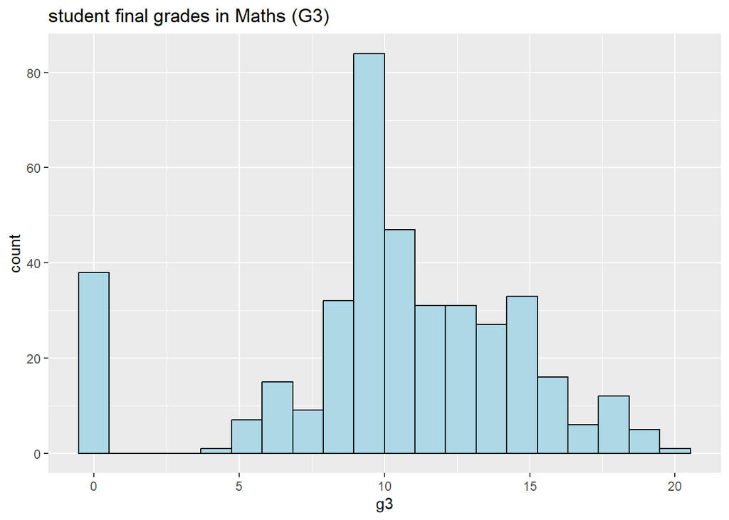

```r
# histogram of G3 grades in Maths
ggplot(Maths, aes(g3)) +
  geom_histogram(bins = 20, fill = "light blue", color = "black") +
  labs(title = "student final grades in Maths (G3)")
```

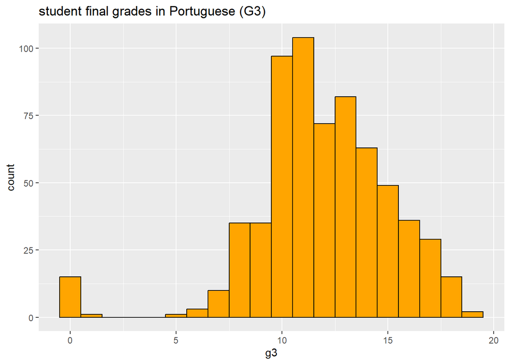

```r
# histogram of G3 grades in Portuguese
ggplot(Portuguese, aes(g3)) +
  geom_histogram(bins = 20, fill = "orange", color = "black") +
  labs(title = "student final grades in Portuguese (G3)")
```

### Correlation Matrix of the Variables

We can also look at make a correlation matrix to see the relationship between each of the variables in the datasets.

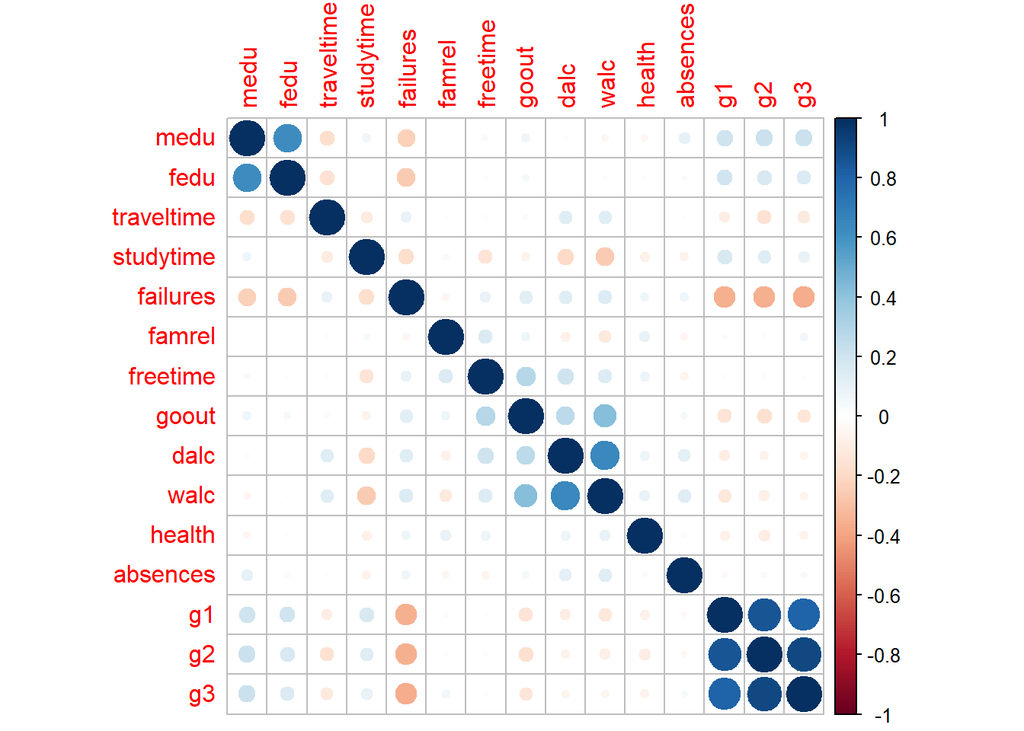

```r
# handle non-numeric variables
Maths_numeric <- Maths %>% select(-school, -sex, -age, -address, -famsize, -pstatus, -mjob, -fjob, -reason, -guardian, -schoolsup, -famsup, -paid, -activities, -nursery, -higher, -internet, -romantic)

# Maths correlation matrix
Maths_cor = cor(Maths_numeric)
corrplot(Maths_cor)
```

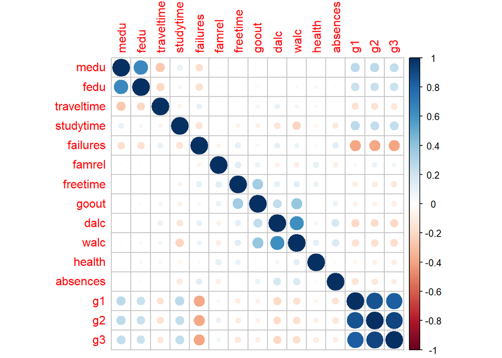

```r
# handle non-numeric variables
Portuguese_numeric <- Portuguese %>% select(-school, -sex, -age, -address, -famsize, -pstatus, -mjob, -fjob, -reason, -guardian, -schoolsup, -famsup, -paid, -activities, -nursery, -higher, -internet, -romantic)

# Portuguese correlation matrix
Portuguese_cor = cor(Portuguese_numeric)
corrplot(Portuguese_cor)
```

Most predictors are not very strongly correlated with G3 grades. However, when looking back and forth between the two matrices, the first thing I notice is that several of the predictors are more strongly correlated (both negatively and positively) in the Portuguese dataset than the Maths dataset. You can tell by the color and size of the dots. Some of the dots in the Portuguese correlation matrix tend to be darker in color and larger in size. One example of this is relationship between G1, G2 grades and failures. Are there any other relationships that stand out to you?

Let’s get more specific and make some graphs of the variables that are most strongly related with G3. This would be G1, G2 grades and failures. We can start with the Maths dataset.

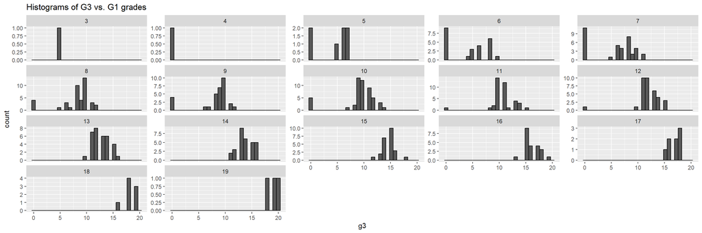

```r
# g1
ggplot(Maths_numeric, aes(g3)) +
  geom_histogram(bins = 30, color = "black") +
  facet_wrap(~g1, scales = "free_y") +
  labs(title = "Histograms of G3 vs. G1 grades")
```

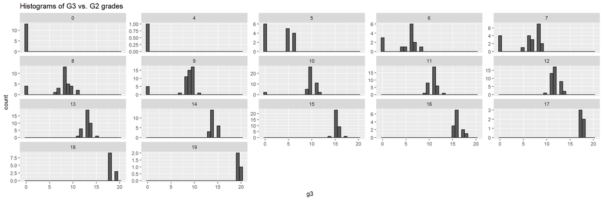

```r
# g2
ggplot(Maths_numeric, aes(g3)) +
  geom_histogram(bins = 30, color = "black") +
  facet_wrap(~g2, scales = "free_y") +
  labs(title = "Histograms of G3 vs. G2 grades")
```

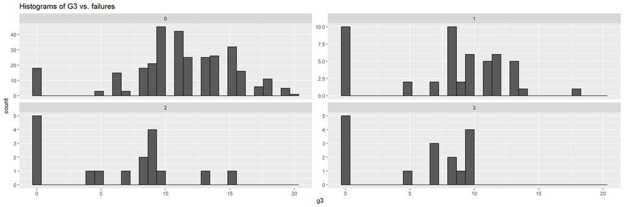

```r
# failures
ggplot(Maths_numeric, aes(g3)) +
  geom_histogram(bins = 30, color = "black") +
  facet_wrap(~failures, scales = "free_y") +
  labs(title = "Histograms of G3 vs. failures")
```

It appears that G1 grades are more widely dispersed (the bars are more spread out) than G2 grades. Generally, lower number of failures correlates with higher G3 grades, which makes sense. Something interesting is that the G3 grades of students who have 0 past failures vary much more than students who have 1 or more failures. For instance, the G3 grades of students with 0 past failures range from 0 all the way to 20. Whereas students with 3 past failures did not receive a G3 grade higher than 10. What are some possible reasons for this?

How will the histograms for the Portuguese dataset compare? Let’s check it out.

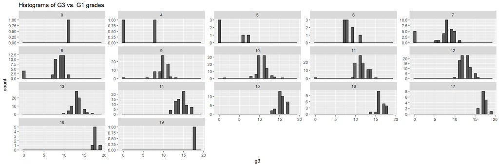

```r
# g1
ggplot(Portuguese_numeric, aes(g3)) +
  geom_histogram(bins = 30, color = "black") +
  facet_wrap(~g1, scales = "free_y") +
  labs(title = "Histograms of G3 vs. G1 grades")
```

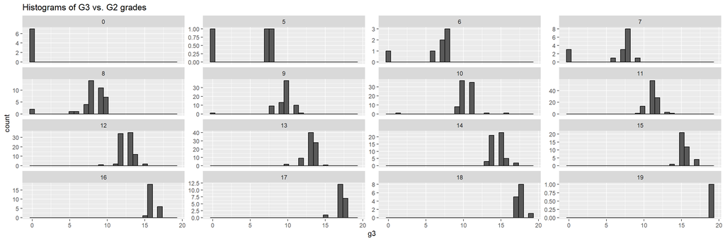

```r
# g2
ggplot(Portuguese_numeric, aes(g3)) +
  geom_histogram(bins = 30, color = "black") +
  facet_wrap(~g2, scales = "free_y") +
  labs(title = "Histograms of G3 vs. G2 grades")
```

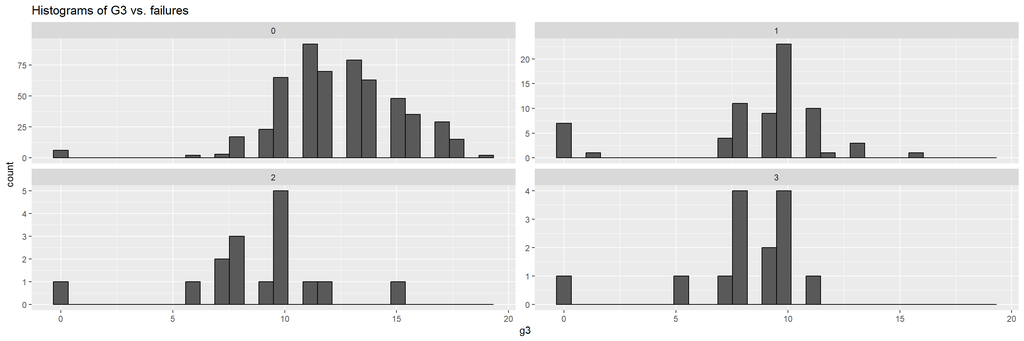

```r
# failures
ggplot(Portuguese_numeric, aes(g3)) +
  geom_histogram(bins = 30, color = "black") +
  facet_wrap(~failures, scales = "free_y") +
  labs(title = "Histograms of G3 vs. failures")
```

Paying close attention, we’ll notice that same trend of how G1 grades are widely dispersed than G2 grades, just like we saw with the Maths dataset. More specifically, it looks like there were no students at all who received a G2 grade of 4, whereas there were G1 grades of 4. Perhaps this is a sign that in the data collected, there are not enough students earning in each “grade category” to be proportional.

As we mentioned earlier, the goal of using this data will be using our predictor variables (ex. school, sex, age, address, family size, parental status, mother’s education, father’s education, etc.) to predict a student’s G3 (final grade) grade/whether a student will pass the class. As we look through the variables, we see that G1 and G2 grades are included. This is great because they will help us in predicting G3 grades.

Let’s add a variable called “course” so we know which observations are from which dataset. This will be important when we merge and split the dataset, we will want to keep track.

```r
# add course = "Maths" as a predictor to label the dataset
course <- rep("maths", times=395)
Maths_new <- cbind(Maths, course)
Maths_new <- clean_names(Maths_new)
Maths_new %>% head()
```

```
##   school sex age address famsize pstatus medu fedu     mjob     fjob     reason
## 1     GP   F  18       U     GT3       A    4    4  at_home  teacher     course
## 2     GP   F  17       U     GT3       T    1    1  at_home    other     course
## 3     GP   F  15       U     LE3       T    1    1  at_home    other      other
## 4     GP   F  15       U     GT3       T    4    2   health services       home
## 5     GP   F  16       U     GT3       T    3    3    other    other       home
## 6     GP   M  16       U     LE3       T    4    3 services    other reputation
##   guardian traveltime studytime failures schoolsup famsup paid activities
## 1   mother          2         2        0       yes     no   no         no
## 2   father          1         2        0        no    yes   no         no
## 3   mother          1         2        3       yes     no  yes         no
## 4   mother          1         3        0        no    yes  yes        yes
## 5   father          1         2        0        no    yes  yes         no
## 6   mother          1         2        0        no    yes  yes        yes
##   nursery higher internet romantic famrel freetime goout dalc walc health
## 1     yes    yes       no       no      4        3     4    1    1      3
## 2      no    yes      yes       no      5        3     3    1    1      3
## 3     yes    yes      yes       no      4        3     2    2    3      3
## 4     yes    yes      yes      yes      3        2     2    1    1      5
## 5     yes    yes       no       no      4        3     2    1    2      5
## 6     yes    yes      yes       no      5        4     2    1    2      5
##   absences g1 g2 g3 course
## 1        6  5  6  6  maths
## 2        4  5  5  6  maths
## 3       10  7  8 10  maths
## 4        2 15 14 15  maths
## 5        4  6 10 10  maths
## 6       10 15 15 15  maths
```

```r
# add course = "Portuguese" as a predictor to label the dataset
course <- rep("portuguese", times=649)
Portuguese_new <- cbind(Portuguese, course)
Portuguese_new <- clean_names(Portuguese_new)
Portuguese_new %>% head()
```

```
##   school sex age address famsize pstatus medu fedu     mjob     fjob     reason
## 1     GP   F  18       U     GT3       A    4    4  at_home  teacher     course
## 2     GP   F  17       U     GT3       T    1    1  at_home    other     course
## 3     GP   F  15       U     LE3       T    1    1  at_home    other      other
## 4     GP   F  15       U     GT3       T    4    2   health services       home
## 5     GP   F  16       U     GT3       T    3    3    other    other       home
## 6     GP   M  16       U     LE3       T    4    3 services    other reputation
##   guardian traveltime studytime failures schoolsup famsup paid activities
## 1   mother          2         2        0       yes     no   no         no
## 2   father          1         2        0        no    yes   no         no
## 3   mother          1         2        0       yes     no   no         no
## 4   mother          1         3        0        no    yes   no        yes
## 5   father          1         2        0        no    yes   no         no
## 6   mother          1         2        0        no    yes   no        yes
##   nursery higher internet romantic famrel freetime goout dalc walc health
## 1     yes    yes       no       no      4        3     4    1    1      3
## 2      no    yes      yes       no      5        3     3    1    1      3
## 3     yes    yes      yes       no      4        3     2    2    3      3
## 4     yes    yes      yes      yes      3        2     2    1    1      5
## 5     yes    yes       no       no      4        3     2    1    2      5
## 6     yes    yes      yes       no      5        4     2    1    2      5
##   absences g1 g2 g3     course
## 1        4  0 11 11 portuguese
## 2        2  9 11 11 portuguese
## 3        6 12 13 12 portuguese
## 4        0 14 14 14 portuguese
## 5        0 11 13 13 portuguese
## 6        6 12 12 13 portuguese
```

### How should we split the 2 datasets?

Since we have 2 datasets and not just 1, there are more options with how we can split and use them. Let’s try two different ways: 1. Method 1 will be to take both the Maths and Portuguese datasets and merge them into one big dataset. 2. Method 2 will be to use one dataset to train, and the other to test our models. I will be using Portuguese to train and Maths to test because Portuguese has more observations (the proportion of training data should be bigger than the proportion of testing data!)

We can fit the models to both methods of data splitting to see which gives us more accurate predictions.

#### Method 1. Merging the data

For method 1, let’s merge both Maths and Portuguese into one large dataset. Mainly we will be working with the data that is labeled by course. After merging, split the merged dataset into training dataset and testing dataset, stratifying on G3, our outcome variable. Stratifying on G3 helps us keep the proportions of the original dataset when we split into training and testing! (You’ll notice I’m also merging the data that doesn’t have the course variable because I’ll need to use it later on.)

```r
# merge non-labeled datasets into one large dataset
all_classes <- rbind(Maths, Portuguese) # for train/test use later on in the project
all_classes %>% head()
```

```
## # A tibble: 6 × 33
##   school sex     age address famsize pstatus  medu  fedu mjob     fjob    reason
##   <chr>  <chr> <dbl> <chr>   <chr>   <chr>   <dbl> <dbl> <chr>    <chr>   <chr>
## 1 GP     F        18 U       GT3     A           4     4 at_home  teacher course
## 2 GP     F        17 U       GT3     T           1     1 at_home  other   course
## 3 GP     F        15 U       LE3     T           1     1 at_home  other   other
## 4 GP     F        15 U       GT3     T           4     2 health   servic… home
## 5 GP     F        16 U       GT3     T           3     3 other    other   home
## 6 GP     M        16 U       LE3     T           4     3 services other   reput…
## # … with 22 more variables: guardian <chr>, traveltime <dbl>, studytime <dbl>,
## #   failures <dbl>, schoolsup <chr>, famsup <chr>, paid <chr>,
## #   activities <chr>, nursery <chr>, higher <chr>, internet <chr>,
## #   romantic <chr>, famrel <dbl>, freetime <dbl>, goout <dbl>, dalc <dbl>,
## #   walc <dbl>, health <dbl>, absences <dbl>, g1 <dbl>, g2 <dbl>, g3 <dbl>
```

```r
# merge course labeled datasets into one large dataset
all_classes2 <- rbind(Maths_new, Portuguese_new)
all_classes2 %>% head()
```

```
##   school sex age address famsize pstatus medu fedu     mjob     fjob     reason
## 1     GP   F  18       U     GT3       A    4    4  at_home  teacher     course
## 2     GP   F  17       U     GT3       T    1    1  at_home    other     course
## 3     GP   F  15       U     LE3       T    1    1  at_home    other      other
## 4     GP   F  15       U     GT3       T    4    2   health services       home
## 5     GP   F  16       U     GT3       T    3    3    other    other       home
## 6     GP   M  16       U     LE3       T    4    3 services    other reputation
##   guardian traveltime studytime failures schoolsup famsup paid activities
## 1   mother          2         2        0       yes     no   no         no
## 2   father          1         2        0        no    yes   no         no
## 3   mother          1         2        3       yes     no  yes         no
## 4   mother          1         3        0        no    yes  yes        yes
## 5   father          1         2        0        no    yes  yes         no
## 6   mother          1         2        0        no    yes  yes        yes
##   nursery higher internet romantic famrel freetime goout dalc walc health
## 1     yes    yes       no       no      4        3     4    1    1      3
## 2      no    yes      yes       no      5        3     3    1    1      3
## 3     yes    yes      yes       no      4        3     2    2    3      3
## 4     yes    yes      yes      yes      3        2     2    1    1      5
## 5     yes    yes       no       no      4        3     2    1    2      5
## 6     yes    yes      yes       no      5        4     2    1    2      5
##   absences g1 g2 g3 course
## 1        6  5  6  6  maths
## 2        4  5  5  6  maths
## 3       10  7  8 10  maths
## 4        2 15 14 15  maths
## 5        4  6 10 10  maths
## 6       10 15 15 15  maths
```

```r
# split labeled, merged dataset into training and testing
set.seed(3435)
grades_split <- initial_split(all_classes2, prop = 0.7,
                              strata = g3)
grades_train <- training(grades_split)
grades_test <- testing(grades_split)
```

#### Method 2. Using one dataset for training, using one dataset for testing

For method 2, let’s take the large merged dataset we made in the previous step. To use Portuguese for training and Maths for testing, I’m going to group the data by the course variable when we split. With a little bit of math, we can calculate exactly where to split the data so the training is Portuguese data and testing is Maths data. We can check that we split the data correctly by verifying the number of observations in grades_train2 and grades_test2 matches the number of observations in Portuguese and Maths. Which it does! Next, I’m going to remove the course labels from the training and testing datasets, because this may cause problems later on when we try to compare predictions with the training/testing data.

```r
# split labeled dataset by "course" predictor
set.seed(3435)
# Portuguese has 649 observations, Math has 395 observations -> Portuguese/(Portuguese and Math) = 649/1044 = 0.62
grades_split2 <- group_initial_split(all_classes2, group = course,
                                     prop = 0.6234)

# use Portuguese for training
grades_train2 <- training(grades_split2)
# use Maths for testing
grades_test2 <- testing(grades_split2)

# verify number of observations
dim(grades_train2) # all Portuguese observations
```

```
## [1] 649  34
```

```r
dim(grades_test2) # all Maths observations
```

```
## [1] 395  34
```

```r
# remove course labels (may cause problems when we train/test)
grades_train2_nocourse <- grades_train2 %>%
  select(-course)
grades_test2_nocourse <- grades_test2 %>%
  select(-course)
```

## Should we choose Regression or Classification?

The next tricky question is: Should we use regression or classification? Technically G3 grades are discrete, for example a student can get a grade of 0, 1, 4, 5, but nothing like 1.5 or 4.33. However, from our histogram earlier, we saw that some grades are more commonly earned than others. Specifically, many students earn grades of 0, 9 or 10, but there are very few/no students who earn a grade of 4. Because the grades are so disproportionately spread out, this might cause a problem if we use a classification model. There wouldn’t be “enough” grades in each level/category for the model to be trained well. Because of this problem, let’s try fitting models in both regression and classification.

Note: I will be fitting two models per method. (ex. linear regression model for Method 1. merged dataset, linear regression model for Method 2. Portuguese=training, Maths=testing) We will then compare the models to see which method gives us better predictions.

## Regression

We will make 2 recipes, the first one we use when working with Method 1. merged dataset (has course variable) and the second we use when working with Method 2. Portuguese for training, Maths for testing (without course variable).

This is because for Method 2, we split the data into training/testing by course. However, when we fit models and predict, having course=Portuguese for training and course=Math for testing throws an error because the model won’t know how to carry over its knowledge when there is only one level (Portuguese) in the training data, and one level (Maths) in the testing data. Therefore we need this 2nd recipe without the course variable, and we need grades_train2_nocourse and grades_test2_nocourse to fit the model.

```r
# recipe for Method 1. merged dataset
grades_recipe1 <- recipe(g3 ~ ., data=all_classes2) %>%
  step_dummy(all_nominal_predictors())

# recipe for Method 2. Portuguese for training, Maths for testing
grades_recipe2 <- recipe(g3 ~ ., data=all_classes) %>%
  step_dummy(all_nominal_predictors())
```

### Linear Regression

We’ll begin with linear regression. We set the engine for linear regression “lm”, create a workflow with the recipe we made, and fit the training data to the model. Then we can bind our predicted values to the actual observations to see how the model performed.

#### Method 1. merged dataset

```r
lm_model <- linear_reg() %>%
  set_engine("lm")

# create workflow
lm_wflow <- workflow() %>%
  add_model(lm_model) %>%
  add_recipe(grades_recipe1)

# fit
lm_fit <- fit(lm_wflow, grades_train)

lm_fit %>%
  # This returns the parsnip object:
  extract_fit_parsnip() %>%
  # Now tidy the linear model object:
  tidy()
```

```
## # A tibble: 43 × 5
##    term        estimate std.error statistic p.value
##    <chr>          <dbl>     <dbl>     <dbl>   <dbl>
##  1 (Intercept) -0.880      1.21     -0.729  0.466
##  2 age         -0.0528     0.0593   -0.892  0.373
##  3 medu        -0.0792     0.0910   -0.871  0.384
##  4 fedu         0.00887    0.0812    0.109  0.913
##  5 traveltime   0.166      0.0939    1.77   0.0776
##  6 studytime    0.00363    0.0836    0.0434 0.965
##  7 failures    -0.301      0.108    -2.80   0.00531
##  8 famrel       0.191      0.0711    2.69   0.00732
##  9 freetime     0.0134     0.0670    0.200  0.841
## 10 goout       -0.0200     0.0623   -0.321  0.749
## # … with 33 more rows
```

```r
# put predictions and actual observations together
grades_train_res <- predict(lm_fit, new_data = grades_train %>% select(-g3))
grades_train_res <- bind_cols(grades_train_res, grades_train %>% select(g3))
grades_train_res %>%
  head()
```

```
## # A tibble: 6 × 2
##   .pred    g3
##   <dbl> <dbl>
## 1  5.41     6
## 2  4.57     6
## 3  8.66    10
## 4  4.50     6
## 5  9.93    10
## 6  3.95     5
```

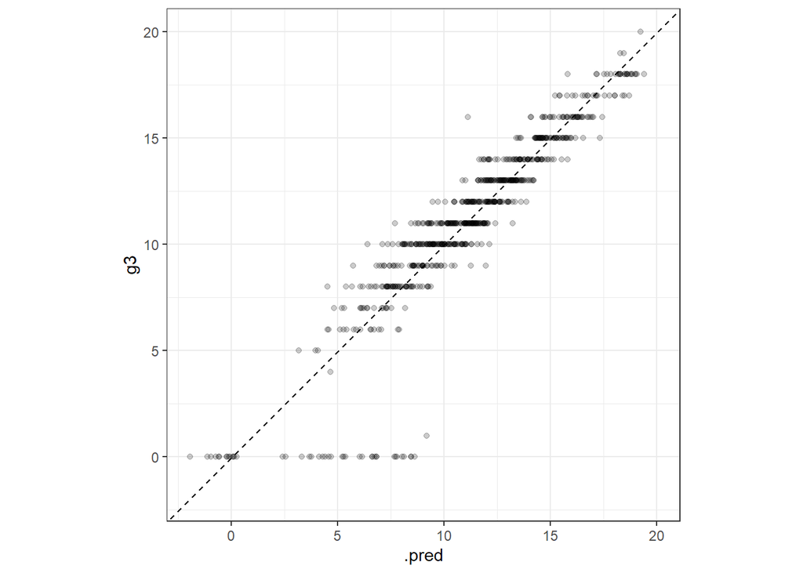

```r
# plot to visualize
grades_train_res %>%
  ggplot(aes(x = .pred, y = g3)) +
  geom_point(alpha = 0.2) +
  geom_abline(lty = 2) +
  theme_bw() +
  coord_obs_pred()
```

```r
# our metrics
grades_metrics1 <- metric_set(rmse, rsq, mae)
grades_metrics1(grades_train_res, truth = g3,
                estimate = .pred)
```

```
## # A tibble: 3 × 3
##   .metric .estimator .estimate
##   <chr>   <chr>          <dbl>
## 1 rmse    standard       1.58
## 2 rsq     standard       0.843
## 3 mae     standard       0.971
```

We also have a plot of our predictions to the actual G3 grades. The model was on the right track, but isn’t completely accurate. (hypothetically then all the dots would fall on the dotted line) It looks like the model was especially bad at predicting G3 grades of 0.

#### Method 2. Portuguese for training, Maths for testing

Here, we repeat the process of setting the engine, creating workflow, and fitting the model like we did above. Except this time we use the training dataset from Method 2.

```r
lm_model <- linear_reg() %>%
  set_engine("lm")

# create workflow
lm_wflow2 <- workflow() %>%
  add_model(lm_model) %>%
  add_recipe(grades_recipe2)

# fit
lm_fit <- fit(lm_wflow2, grades_train2_nocourse)

lm_fit %>%
  # This returns the parsnip object:
  extract_fit_parsnip() %>%
  # Now tidy the linear model object:
  tidy()
```

```
## # A tibble: 42 × 5
##    term        estimate std.error statistic p.value
##    <chr>          <dbl>     <dbl>     <dbl>   <dbl>
##  1 (Intercept)   0.638     0.964      0.662  0.508
##  2 age           0.0287    0.0484     0.593  0.553
##  3 medu         -0.0917    0.0710    -1.29   0.197
##  4 fedu          0.0496    0.0646     0.768  0.443
##  5 traveltime    0.139     0.0746     1.86   0.0637
##  6 studytime     0.0496    0.0662     0.750  0.454
##  7 failures     -0.255     0.0990    -2.58   0.0103
##  8 famrel       -0.0160    0.0547    -0.292  0.770
##  9 freetime     -0.0500    0.0527    -0.950  0.343
## 10 goout        -0.0189    0.0504    -0.375  0.708
## # … with 32 more rows
```

```r
# put predictions and actual observations together
grades_train_res2 <- predict(lm_fit, new_data = grades_train2 %>% select(-g3))
grades_train_res2 <- bind_cols(grades_train_res2, grades_train2_nocourse %>% select(g3))
grades_train_res2 %>%
  head()
```

```
## # A tibble: 6 × 2
##   .pred    g3
##   <dbl> <dbl>
## 1  9.94    11
## 2 11.6     11
## 3 13.0     12
## 4 14.5     14
## 5 13.0     13
## 6 12.4     13
```

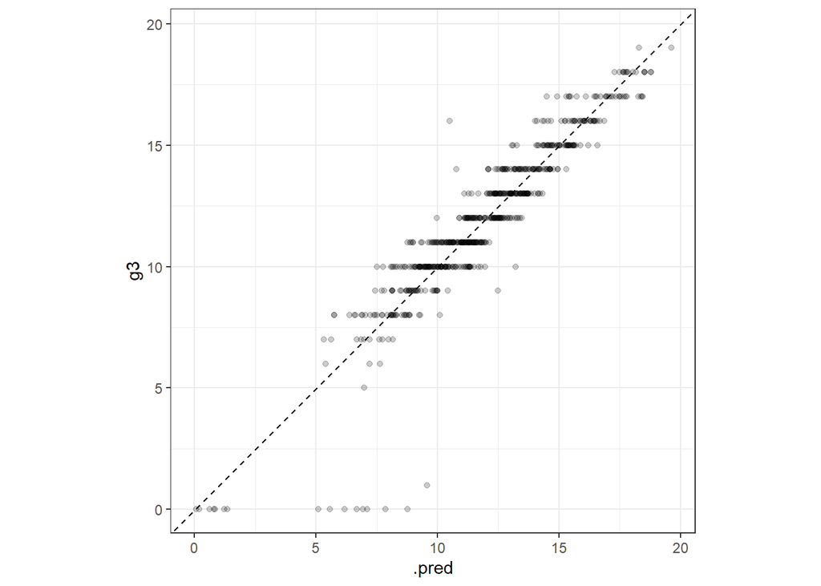

```r
# plot to visualize
grades_train_res2 %>%
  ggplot(aes(x = .pred, y = g3)) +
  geom_point(alpha = 0.2) +
  geom_abline(lty = 2) +
  theme_bw() +
  coord_obs_pred()
```

```r
# our metrics
grades_metrics2 <- metric_set(rmse, rsq, mae)
grades_metrics2(grades_train_res2, truth = g3,
                estimate = .pred)
```

```
## # A tibble: 3 × 3
##   .metric .estimator .estimate
##   <chr>   <chr>          <dbl>
## 1 rmse    standard       1.21
## 2 rsq     standard       0.860
## 3 mae     standard       0.762
```

The plot shows that the Method 2 model is also quite bad at predicting G3 grades of 0, for other grades it does a little better, but still not the kind of accuracy we’re looking for.

From our two linear regression models above, we see that both have values of rmse of greater than 1. This shows that the model didn’t perform particularly well, or isn’t optimized well. We have a high rmse, and generally the closer rmse is to 0, the better our model is. We also have a high mae, which isn’t great because the closer mae is to 0, the better. Between the two models, it looks like Method 2 gave us better predictions. Let’s try some classification methods instead and see if they perform better!

## Classification

Before we try fitting classification methods, we should remember the issue discussed earlier. For classification methods, we will need to convert G3 grades to a factor type with different levels. However, because some grades were “more common” (earned by more students than others), there may not be enough student grades data in each “grade category”. (ex. grade 0, grade 1, grade 2, etc.) If we create a level for each individual grade, we will run into the problem of disproportionate categories. Instead, (advised by my TA Hanmo) we can group the G3 grades into two levels of “Pass” and “Fail.” The split between “Pass” and “Fail” is arbitrarily decided, it can be changed depending on the context/use of the model. I chose to group grades 0-10 as “Fail”, and grades 11-20 as “Pass.” Creating new factor levels will group much more data together and hopefully solve the problem of not having enough student grades in each level.

Before we fit any models however, we need to convert our outcome variable G3 into a factor and give it the new levels of “Pass” and “Fail.” Be sure to check that the new factor levels have been assigned correctly!

```r
# convert outcome variable to factor first!

# Method 1. dataset without course labels
all_classes_fctr <- all_classes %>% mutate(g3 = factor(g3))
all_classes_fctr$g3 %>% head()
```

```
## [1] 6  6  10 15 10 15
## Levels: 0 1 4 5 6 7 8 9 10 11 12 13 14 15 16 17 18 19 20
```

```r
# if G3 between 0 and 10, level = Fail, if G3 between 11 and 20, level = Pass
levels(all_classes_fctr$g3) <- list("Fail"="0", "Fail"="1", "Fail"="4", "Fail"="5", "Fail"="6", "Fail"="7", "Fail"="8", "Fail"="9", "Fail"="10", "Pass"="11", "Pass"="12", "Pass"="13", "Pass"="14", "Pass"="15", "Pass"="16", "Pass"="17", "Pass"="18", "Pass"="19", "Pass"="20")

# check that levels were reassigned correctly
all_classes_fctr$g3 %>% head()
```

```
## [1] Fail Fail Fail Pass Fail Pass
## Levels: Fail Pass
```

```r
# Method 2. dataset with course labels
all_classes2_fctr <- all_classes2 %>% mutate(g3 = factor(g3))
all_classes2_fctr$g3 %>% head()
```

```
## [1] 6  6  10 15 10 15
## Levels: 0 1 4 5 6 7 8 9 10 11 12 13 14 15 16 17 18 19 20
```

```r
# if G3 between 0 and 10, level = Fail, if G3 between 11 and 20, level = Pass
levels(all_classes2_fctr$g3) <- list("Fail"="0", "Fail"="1", "Fail"="4", "Fail"="5", "Fail"="6", "Fail"="7", "Fail"="8", "Fail"="9", "Fail"="10", "Pass"="11", "Pass"="12", "Pass"="13", "Pass"="14", "Pass"="15", "Pass"="16", "Pass"="17", "Pass"="18", "Pass"="19", "Pass"="20")

# check that levels were reassigned correctly
all_classes2_fctr$g3 %>% head()
```

```
## [1] Fail Fail Fail Pass Fail Pass
## Levels: Fail Pass
```

We take our datasets with the new factor outcome variable and split it with two different ways, just like we did before. Method 1. merged dataset, Method 2. Portuguese = training, Maths = testing

```r
set.seed(3435)

# Method 1. split data into training/testing
grades_split_fctr <- initial_split(all_classes2_fctr, prop = 0.7,
                               strata = g3)
grades_train_fctr <- training(grades_split_fctr)
grades_test_fctr <- testing(grades_split_fctr)


# Method 2. split data into training/testing
grades_split2_fctr <- group_initial_split(all_classes2_fctr, group = course,
                                     prop = 0.6234)
# use Portuguese for training
grades_train2_fctr <- training(grades_split2_fctr)
# use Maths for testing
grades_test2_fctr <- testing(grades_split2_fctr)

# remove course labels (may cause problems when we train/test)
grades_train2_fctr_nocourse <- grades_train2_fctr %>%
  select(-course)
grades_test2_fctr_nocourse <- grades_test2_fctr %>%
  select(-course)
```

Let’s make 2 recipes (like we did above with regression) for the classification models with the data, except this time our outcome variable, G3, is a factor.

```r
# recipe for Method 1. merged dataset
grades_recipe1_fctr <- recipe(g3 ~ ., data=all_classes2_fctr) %>%
  step_dummy(all_nominal_predictors()) %>%
  step_center(all_predictors()) %>% # center predictors
  step_scale(all_predictors()) # scale predictors

# recipe for Method 2. Portuguese for training, Maths for testing
grades_recipe2_fctr <- recipe(g3 ~ ., data=all_classes_fctr) %>%
  step_dummy(all_nominal_predictors()) %>%
  step_center(all_predictors()) %>% # center predictors
  step_scale(all_predictors()) # scale predictors
```

For the classification models, here are the steps we need to take:

1. Set up the model by specifying the model type, engine, and mode.
2. Set up the workflow, add the new model, and add the established recipe.

*Skip steps 3-5 for Log Regression, LDA, and QDA

3. Set up the tuning grid with the parameters and different levels of tuning we want.
4. Tune the model with certain parameters of choice.
5. Select the most accurate model from all of the tuning, finalize the workflow.
6. Fit that model to the training data set.
7. Save the results to file to cut down on runtime when we rerun the code.
8. Repeat steps for Method 2, we need to try both methods to see which one gives more accurate results.

Let’s begin with logistic regression. Then we’ll try linear discriminant analysis (LDA) and quadratic discriminant analysis (QDA). Lastly, we can fit our data in folds to the method that works the best.

### Logistic Regression

Just like we did with linear regression, for logistic regression we begin by setting the appropriate engine “glm”, creating a workflow, and adding the new recipe we created. Then we fit the model to the training data. Here I’ve created a confusion matrix and calculated the accuracy, roc_auc to give a better idea of how the model performed.

#### Method 1. merged dataset

```r
log_reg <- logistic_reg() %>%
  set_engine("glm")

# create workflow
log_wkflow <- workflow() %>%
  add_model(log_reg) %>%
  add_recipe(grades_recipe1_fctr)

# fit
log_fit <- fit(log_wkflow, grades_train_fctr)
log_fit %>%
  tidy()
```

```
## # A tibble: 43 × 5
##    term        estimate std.error statistic  p.value
##    <chr>          <dbl>     <dbl>     <dbl>    <dbl>
##  1 (Intercept)  2.53        0.309    8.17   2.98e-16
##  2 age          0.0717      0.221    0.324  7.46e- 1
##  3 medu        -0.0498      0.325   -0.153  8.78e- 1
##  4 fedu         0.0415      0.278    0.149  8.81e- 1
##  5 traveltime   0.0212      0.189    0.112  9.11e- 1
##  6 studytime    0.00703     0.221    0.0318 9.75e- 1
##  7 failures    -0.540       0.263   -2.05   3.99e- 2
##  8 famrel       0.171       0.224    0.763  4.46e- 1
##  9 freetime     0.131       0.193    0.679  4.97e- 1
## 10 goout        0.258       0.219    1.18   2.40e- 1
## # … with 33 more rows
```

```r
# predictions
predict(log_fit, new_data = grades_train_fctr, type = "prob") %>% head()
```

```
## # A tibble: 6 × 2
##   .pred_Fail  .pred_Pass
##        <dbl>       <dbl>
## 1      1.00  0.0000627
## 2      1.00  0.0000320
## 3      0.822 0.178
## 4      1.00  0.0000124
## 5      0.795 0.205
## 6      1.00  0.000000262
```

```r
# confusion matrix
augment(log_fit, new_data = grades_train_fctr) %>%
  conf_mat(truth = g3, estimate = .pred_class)
```

```
##           Truth
## Prediction Fail Pass
##       Fail  242   23
##       Pass   26  439
```

```r
# accuracy and roc_auc
augment(log_fit, new_data = grades_train_fctr) %>%
  accuracy(truth = g3, estimate = .pred_class)
```

```
## # A tibble: 1 × 3
##   .metric  .estimator .estimate
##   <chr>    <chr>          <dbl>
## 1 accuracy binary         0.933
```

```r
augment(log_fit, new_data = grades_train_fctr) %>%
  roc_auc(truth = g3, estimate = .pred_Fail)
```

```
## # A tibble: 1 × 3
##   .metric .estimator .estimate
##   <chr>   <chr>          <dbl>
## 1 roc_auc binary         0.985
```

#### Method 2. Portuguese for training, Maths for testing

Repeat the same steps for Method 2:

```r
log_reg <- logistic_reg() %>%
  set_engine("glm")

# create workflow
log_wkflow2 <- workflow() %>%
  add_model(log_reg) %>%
  add_recipe(grades_recipe2_fctr)

# fit
log_fit2 <- fit(log_wkflow2, grades_train2_fctr)
log_fit2 %>%
  tidy()
```

```
## # A tibble: 42 × 5
##    term        estimate std.error statistic  p.value
##    <chr>          <dbl>     <dbl>     <dbl>    <dbl>
##  1 (Intercept)   3.49       0.410    8.53   1.43e-17
##  2 age           0.176      0.216    0.817  4.14e- 1
##  3 medu          0.135      0.287    0.470  6.39e- 1
##  4 fedu         -0.0507     0.263   -0.193  8.47e- 1
##  5 traveltime    0.297      0.179    1.66   9.62e- 2
##  6 studytime     0.0186     0.203    0.0914 9.27e- 1
##  7 failures     -0.473      0.230   -2.05   4.01e- 2
##  8 famrel       -0.227      0.204   -1.11   2.67e- 1
##  9 freetime     -0.0800     0.196   -0.409  6.83e- 1
## 10 goout         0.182      0.222    0.817  4.14e- 1
## # … with 32 more rows
```

```r
# predict
predict(log_fit2, new_data = grades_train2_fctr, type = "prob") %>% head()
```

```
## # A tibble: 6 × 2
##   .pred_Fail .pred_Pass
##        <dbl>      <dbl>
## 1   0.319         0.681
## 2   0.0691        0.931
## 3   0.00160       0.998
## 4   0.000278      1.00
## 5   0.000481      1.00
## 6   0.0335        0.967
```

```r
# confusion matrix
augment(log_fit2, new_data = grades_train2_fctr) %>%
  conf_mat(truth = g3, estimate = .pred_class)
```

```
##           Truth
## Prediction Fail Pass
##       Fail  176   23
##       Pass   21  429
```

```r
# accuracy and roc_auc
augment(log_fit2, new_data = grades_train2_fctr) %>%
  accuracy(truth = g3, estimate = .pred_class)
```

```
## # A tibble: 1 × 3
##   .metric  .estimator .estimate
##   <chr>    <chr>          <dbl>
## 1 accuracy binary         0.932
```

```r
augment(log_fit2, new_data = grades_train2_fctr) %>%
  roc_auc(truth = g3, estimate = .pred_Fail)
```

```
## # A tibble: 1 × 3
##   .metric .estimator .estimate
##   <chr>   <chr>          <dbl>
## 1 roc_auc binary         0.977
```

Both data methods gave us roc_auc and accuracies greater than 0.9, that’s really good! Will LDA or QDA give us better results?

### Linear Discriminant Analysis (LDA)

The engine for LDA is “MASS” and remember to set the mode to “classification”! Create a workflow and add the recipe. Then repeat the steps we did with logistic regression.

#### Method 1. merged dataset

```r
lda_mod <- discrim_linear() %>%
  set_mode("classification") %>%
  set_engine("MASS")

# create workflow
lda_wkflow <- workflow() %>%
  add_model(lda_mod) %>%
  add_recipe(grades_recipe1_fctr)

# fit
lda_fit <- fit(lda_wkflow, grades_train_fctr)

# predict
predict(lda_fit, new_data = grades_train_fctr, type = "prob") %>% head()
```

```
## # A tibble: 6 × 2
##   .pred_Fail .pred_Pass
##        <dbl>      <dbl>
## 1      0.998   0.00224
## 2      0.993   0.00665
## 3      0.832   0.168
## 4      0.997   0.00334
## 5      0.764   0.236
## 6      1.00    0.000173
```

```r
# confusion matrix
augment(lda_fit, new_data = grades_train_fctr) %>%
  conf_mat(truth = g3, estimate = .pred_class)
```

```
##           Truth
## Prediction Fail Pass
##       Fail  229   21
##       Pass   39  441
```

```r
# accuracy and roc_auc
augment(lda_fit, new_data = grades_train_fctr) %>%
  accuracy(truth = g3, estimate = .pred_class)
```

```
## # A tibble: 1 × 3
##   .metric  .estimator .estimate
##   <chr>    <chr>          <dbl>
## 1 accuracy binary         0.918
```

```r
augment(lda_fit, new_data = grades_train_fctr) %>%
  roc_auc(truth = g3, estimate = .pred_Fail)
```

```
## # A tibble: 1 × 3
##   .metric .estimator .estimate
##   <chr>   <chr>          <dbl>
## 1 roc_auc binary         0.975
```

#### Method 2. Portuguese for training, Maths for testing

Repeat the same steps for Method 2:

```r
lda_mod <- discrim_linear() %>%
  set_mode("classification") %>%
  set_engine("MASS")

# create workflow
lda_wkflow2 <- workflow() %>%
  add_model(lda_mod) %>%
  add_recipe(grades_recipe2_fctr)

# fit
lda_fit2 <- fit(lda_wkflow2, grades_train2_fctr)

# predict
predict(lda_fit2, new_data = grades_train2_fctr, type = "prob") %>% head()
```

```
## # A tibble: 6 × 2
##   .pred_Fail .pred_Pass
##        <dbl>      <dbl>
## 1    0.845        0.155
## 2    0.0876       0.912
## 3    0.0334       0.967
## 4    0.00874      0.991
## 5    0.00414      0.996
## 6    0.0642       0.936
```

```r
# confusion matrix
augment(lda_fit2, new_data = grades_train2_fctr) %>%
  conf_mat(truth = g3, estimate = .pred_class)
```

```
##           Truth
## Prediction Fail Pass
##       Fail  149   22
##       Pass   48  430
```

```r
# accuracy and roc_auc
augment(lda_fit2, new_data = grades_train2_fctr) %>%
  accuracy(truth = g3, estimate = .pred_class)
```

```
## # A tibble: 1 × 3
##   .metric  .estimator .estimate
##   <chr>    <chr>          <dbl>
## 1 accuracy binary         0.892
```

```r
augment(lda_fit2, new_data = grades_train2_fctr) %>%
  roc_auc(truth = g3, estimate = .pred_Fail)
```

```
## # A tibble: 1 × 3
##   .metric .estimator .estimate
##   <chr>   <chr>          <dbl>
## 1 roc_auc binary         0.965
```

The roc_auc from logistic regression are slightly higher than those from LDA, and in contrast, the accuracies from LDA are slightly lower than what we got for logistic regression. If we were to pick one of the two models, we should probably go with logistic regression, because it is very similar to LDA, but less complex in some aspects. But before we choose, let’s check QDA too.

### Quadratic Discriminant Analysis (QDA)

#### Method 1. merged dataset

Similar to LDA, the QDA engine is “MASS” and mode is “classification”. But pay attention because instead of discrim_linear(), we are using discrim_quad() for QDA. The rest of the steps are same as we did before.

```r
qda_mod <- discrim_quad() %>%
  set_mode("classification") %>%
  set_engine("MASS")

# create workflow
qda_wkflow <- workflow() %>%
  add_model(qda_mod) %>%
  add_recipe(grades_recipe1_fctr) # recipe from before

# fit
qda_fit <- fit(qda_wkflow, grades_train_fctr)

# predict
predict(qda_fit, new_data = grades_train_fctr, type = "prob") %>% head()
```

```
## # A tibble: 6 × 2
##   .pred_Fail .pred_Pass
##        <dbl>      <dbl>
## 1      0.999   8.48e- 4
## 2      0.987   1.28e- 2
## 3      0.924   7.59e- 2
## 4      1.00    7.86e- 6
## 5      0.989   1.12e- 2
## 6      1       1.12e-25
```

```r
# confusion matrix
augment(qda_fit, new_data = grades_train_fctr) %>%
  conf_mat(truth = g3, estimate = .pred_class)
```

```
##           Truth
## Prediction Fail Pass
##       Fail  225   25
##       Pass   43  437
```

```r
# accuracy and roc_auc
augment(qda_fit, new_data = grades_train_fctr) %>%
  accuracy(truth = g3, estimate = .pred_class)
```

```
## # A tibble: 1 × 3
##   .metric  .estimator .estimate
##   <chr>    <chr>          <dbl>
## 1 accuracy binary         0.907
```

```r
augment(qda_fit, new_data = grades_train_fctr) %>%
  roc_auc(truth = g3, estimate = .pred_Fail)
```

```
## # A tibble: 1 × 3
##   .metric .estimator .estimate
##   <chr>   <chr>          <dbl>
## 1 roc_auc binary         0.967
```

#### Method 2. Portuguese for training, Maths for testing

Repeat the same steps for Method 2:

```r
qda_mod <- discrim_quad() %>%
  set_mode("classification") %>%
  set_engine("MASS")

# create workflow
qda_wkflow2 <- workflow() %>%
  add_model(qda_mod) %>%
  add_recipe(grades_recipe2_fctr) # recipe from before

# fit
qda_fit2 <- fit(qda_wkflow2, grades_train2_fctr)

# predict
predict(qda_fit2, new_data = grades_train2_fctr, type = "prob") %>% head()
```

```
## # A tibble: 6 × 2
##   .pred_Fail .pred_Pass
##        <dbl>      <dbl>
## 1   8.24e-27      1
## 2   2.62e- 4      1.00
## 3   9.95e- 2      0.901
## 4   5.81e- 8      1.00
## 5   3.66e- 6      1.00
## 6   1.02e- 5      1.00
```

```r
# confusion matrix
augment(qda_fit2, new_data = grades_train2_fctr) %>%
  conf_mat(truth = g3, estimate = .pred_class)
```

```
##           Truth
## Prediction Fail Pass
##       Fail  173   29
##       Pass   24  423
```

```r
# accuracy and roc
augment(qda_fit2, new_data = grades_train2_fctr) %>%
  accuracy(truth = g3, estimate = .pred_class)
```

```
## # A tibble: 1 × 3
##   .metric  .estimator .estimate
##   <chr>    <chr>          <dbl>
## 1 accuracy binary         0.918
```

```r
augment(qda_fit2, new_data = grades_train2_fctr) %>%
  roc_auc(truth = g3, estimate = .pred_Fail)
```

```
## # A tibble: 1 × 3
##   .metric .estimator .estimate
##   <chr>   <chr>          <dbl>
## 1 roc_auc binary         0.964
```

QDA did similarly to LDA in terms of accuracy and roc_auc. From these three models, logistic regression Method 1 gave us the best roc_auc and accuracy.

### K-fold Cross Validation

K-fold cross validation is when we split up the training data into k groups and use certain groups to “validate” or check. This process is often used to train a model more thoroughly when we don’t have enough data. We can try k-fold cross validation on the logistic regression model that performed best out of classification models. Let’s use 10 folds and see if it gives us better results than the model that didn’t use folds.

Before we jump in, first, some definitions. * AUC is the “area under the curve.” “Curve” refers to an ROC curve. AUC represents the model’s capability of distinguishing between classes. In our scenario, AUC is measuring how capable each model is at distinguishing students who “Fail” from students who “Pass.” * We will also be plotting ROC curves. This website says “A ROC curve is constructed by plotting the true positive rate (TPR) against the false positive rate (FPR).” https://www.displayr.com/what-is-a-roc-curve-how-to-interpret-it/ Basically, an ROC curve measures a model’s performance at classifying the data into the correct categories (ex. “Fail”, “Pass”)

#### Method 1. merged dataset

First, use the vfold_cv() function to set the number of folds we want. We’ll use 10, and stratify on g3 to make sure that the folds are proportional to the original training dataset! Set the engine and create the workflow as before, then instead of using fit(), we use fit_resamples() so that R knows we want to fit to the folds of data we set up. We can make a confusion matrix, calculate the accuracy, roc_auc, and plot the ROC curve as well. How did the k-fold cross validation model compare to the original?

```r
set.seed(3435)

# 10-fold cross validation
grades_folds_fctr <- vfold_cv(grades_train_fctr, v = 10, strata = g3)

# logistic regression model
log_reg <- logistic_reg() %>%
  set_engine("glm")

# create workflow
log_wkflow <- workflow() %>%
  add_model(log_reg) %>%
  add_recipe(grades_recipe1_fctr)

# fit to the folds
fit_log_kfold <- fit_resamples(log_wkflow,
                        grades_folds_fctr,
                        control = control_resamples(save_pred = TRUE))

# confusion matrix
augment(fit_log_kfold) %>%
  conf_mat(truth = g3, estimate = .pred_class)
```

```
##           Truth
## Prediction Fail Pass
##       Fail  233   34
##       Pass   35  428
```

```r
# accuracy and roc_auc
augment(fit_log_kfold) %>%
  accuracy(truth = g3, estimate = .pred_class)
```

```
## # A tibble: 1 × 3
##   .metric  .estimator .estimate
##   <chr>    <chr>          <dbl>
## 1 accuracy binary         0.905
```

```r
augment(fit_log_kfold) %>%
  roc_auc(truth = g3, estimate = .pred_Fail)
```

```
## # A tibble: 1 × 3
##   .metric .estimator .estimate
##   <chr>   <chr>          <dbl>
## 1 roc_auc binary         0.969
```

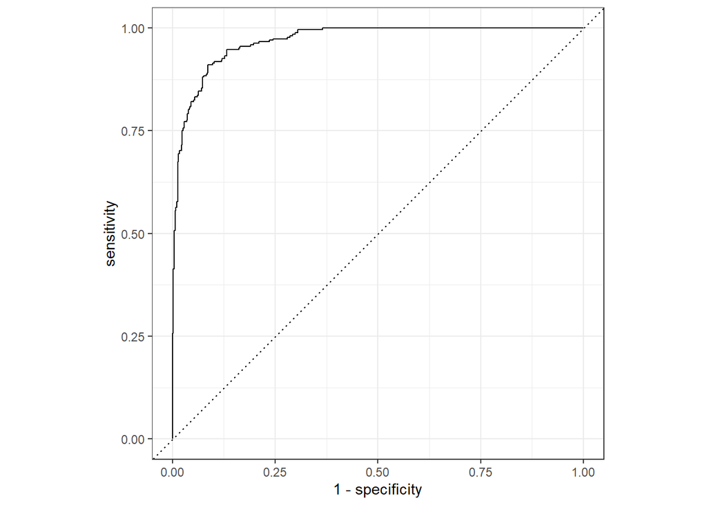

```r
# ROC curve
augment(fit_log_kfold) %>%
  roc_curve(truth = grades_train_fctr$g3, estimate = .pred_Fail) %>%
  autoplot()
```

#### Method 2. Portuguese for training, Maths for testing

```r
set.seed(3435)

# 10-fold cross validation
grades_folds2_fctr <- vfold_cv(grades_train2_fctr, v = 10, strata = g3)

# logistic regression model
log_reg <- logistic_reg() %>%
  set_engine("glm")

# create workflow
log_wkflow2 <- workflow() %>%
  add_model(log_reg) %>%
  add_recipe(grades_recipe2_fctr)

# fit model to folds
fit_log2_kfold <- fit_resamples(log_wkflow2,
                        grades_folds2_fctr,
                        control = control_resamples(save_pred = TRUE))

# confusion matrix
augment(fit_log2_kfold) %>%
  conf_mat(truth = g3, estimate = .pred_class)
```

```
##           Truth
## Prediction Fail Pass
##       Fail  161   35
##       Pass   36  417
```

```r
# accuracy and roc_auc
augment(fit_log2_kfold) %>%
  accuracy(truth = g3, estimate = .pred_class)
```

```
## # A tibble: 1 × 3
##   .metric  .estimator .estimate
##   <chr>    <chr>          <dbl>
## 1 accuracy binary         0.891
```

```r
augment(fit_log2_kfold) %>%
  roc_auc(truth = g3, estimate = .pred_Fail)
```

```
## # A tibble: 1 × 3
##   .metric .estimator .estimate
##   <chr>   <chr>          <dbl>
## 1 roc_auc binary         0.951
```

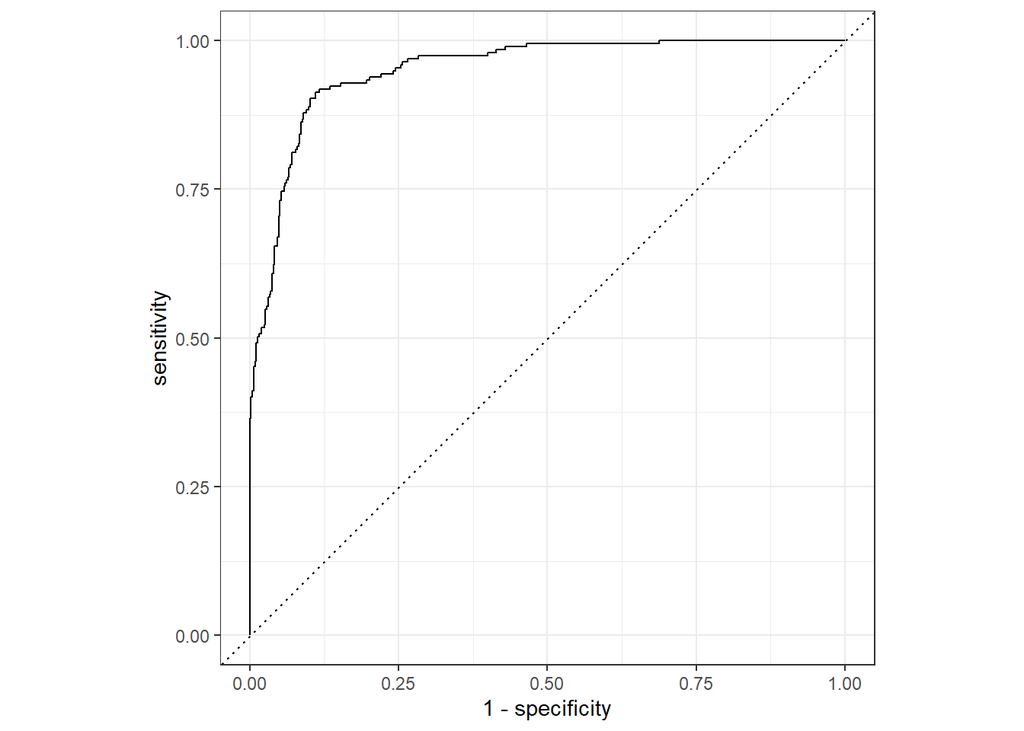

```r
# ROC curve Method 2
augment(fit_log2_kfold) %>%
  roc_curve(truth = grades_train2_fctr$g3, estimate = .pred_Fail) %>%
  autoplot()
```

The ROC curves of two models are extremely similar, with slight variation at the middle of the curve. The roc_auc value for Method 1 is slightly higher than the value for Method 2. This is consistent with the accuracy as well. Did you notice that the accuracy and roc_auc actually went down when we used k-fold cross validation compared to the results from the original logistic regression model? Any ideas on why this might be?

### Elastic Net Tuning

Next, let’s try the elastic net method, where we tune the parameters of mixture and penalty. This is an a model that uses an “in between” penalty term in comparison to ridge and lasso regression (where the penalty terms are 0 and as close to infinity as possible, respectively). * Tuning is the process of: choosing several values of a parameter, fitting the model to those values, and choosing the value that gives use the best result.

#### Method 1. merged dataset

First we prepare our data by splitting into 5-folds for cross validation. Then we set the engine for multinomial regression “glmnet” and mode “classification” with multinom_reg. Create a workflow and add the recipe from earlier. In the elastic net model, We want to tune the mixture and penalty parameters to see which values give us the best results. To do this, we set up a grid, which contains the range of values we want to choose from.

```r
set.seed(3435)

# 5-fold cross validation
grades_folds_fctr_new <- vfold_cv(grades_train_fctr, v = 5, strata = g3)

# elastic net
multinom_reg_model <- multinom_reg(mixture = tune(), penalty = tune()) %>%
  set_mode("classification") %>%
  set_engine("glmnet")

# create workflow
multinom_reg_wf <- workflow() %>%
  add_model(multinom_reg_model) %>% # add model
  add_recipe(grades_recipe1_fctr) # add recipe

# grid for penalty and mixture
grid_pm_en <- grid_regular(mixture(range = c(0, 1)), penalty(range = c(-5, 5)), levels = c(mixture = 10, penalty = 10))
```

tune_grid() is the function that chooses various values of parameters from the grid we created and fits a model for each parameter value.

```r
tune_res_elasticnet <- tune_grid(
  object = multinom_reg_wf,
  resamples = grades_folds_fctr_new,
  grid = grid_pm_en
)

# write file
write_rds(tune_res_elasticnet, file = "C:/Users/cupca/OneDrive/Documents/UCSB/Fall2022/PSTAT131/Final-Project/Final-Project-laurenrhuang/saved_models/tune_res_elasticnet.rds")
```

Models like these which have tuned parameters and involve k-fold cross validation can take longer to run, a good idea would be to save your fitted model to a file so you don’t have to re-fit the model every time you run the code!

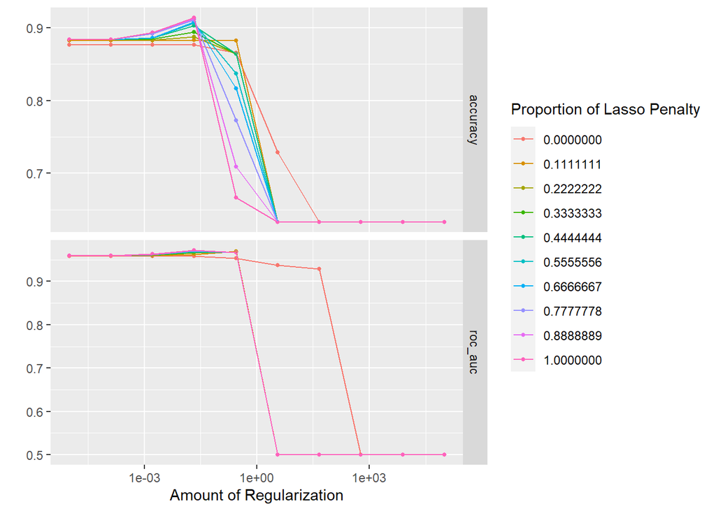

```r
# read file
tune_res_elasticnet <- read_rds(file = "C:/Users/cupca/OneDrive/Documents/UCSB/Fall2022/PSTAT131//Final-Project/Final-Project-laurenrhuang/saved_models/tune_res_elasticnet.rds")

# autoplot
autoplot(tune_res_elasticnet)
```

We can show the parameters that gave us the top results based on roc_auc. Then select the best one, and fit the entire training dataset to the model with the best parameter value.

```r
# show the best models according to roc_auc
show_best(tune_res_elasticnet, metric = "roc_auc")
```

```
## # A tibble: 5 × 8
##   penalty mixture .metric .estimator  mean     n std_err .config
##     <dbl>   <dbl> <chr>   <chr>      <dbl> <int>   <dbl> <chr>
## 1  0.0215   1     roc_auc binary     0.971     5 0.00519 Preprocessor1_Model094
## 2  0.0215   0.889 roc_auc binary     0.971     5 0.00500 Preprocessor1_Model084
## 3  0.0215   0.778 roc_auc binary     0.971     5 0.00471 Preprocessor1_Model074
## 4  0.0215   0.667 roc_auc binary     0.970     5 0.00445 Preprocessor1_Model064
## 5  0.0215   0.556 roc_auc binary     0.969     5 0.00413 Preprocessor1_Model054
```

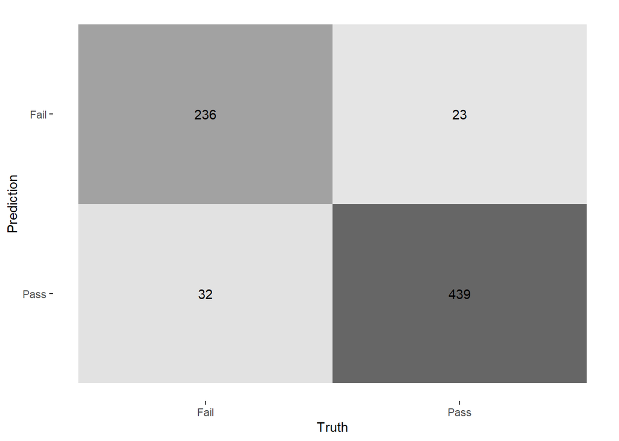

```r
# select the best
en_best_rocauc <- select_best(tune_res_elasticnet, metric = "roc_auc")

# fit model to training set
elasticnet1_final <- finalize_workflow(multinom_reg_wf, en_best_rocauc)
elasticnet1_final_fit <- fit(elasticnet1_final, data = grades_train_fctr)

# confusion matrix
augment(elasticnet1_final_fit, new_data = grades_train_fctr) %>%
  conf_mat(truth = g3, estimate = .pred_class) %>%
  autoplot(type = "heatmap")
```

```r
# evaluate accuracy and roc_auc
augment(elasticnet1_final_fit, new_data = grades_train_fctr) %>%
  accuracy(truth = g3, estimate = .pred_class)
```

```
## # A tibble: 1 × 3
##   .metric  .estimator .estimate
##   <chr>    <chr>          <dbl>
## 1 accuracy binary         0.925
```

```r
augment(elasticnet1_final_fit, new_data = grades_train_fctr) %>%
  roc_auc(truth = g3, estimate = .pred_Fail)
```

```
## # A tibble: 1 × 3
##   .metric .estimator .estimate
##   <chr>   <chr>          <dbl>
## 1 roc_auc binary         0.978
```

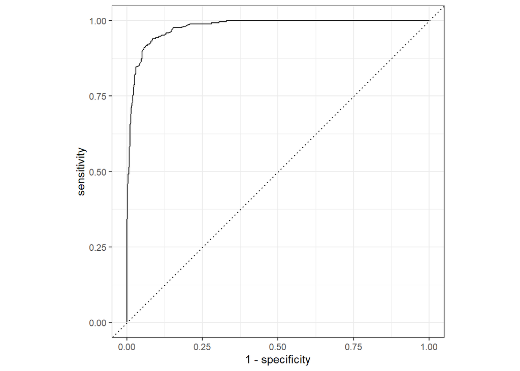

```r
# ROC curve
augment(elasticnet1_final_fit, new_data = grades_train_fctr) %>%
  roc_curve(truth = g3, estimate = .pred_Fail) %>%
  autoplot()
```

After viewing the confucsion matrix, accuracy, roc_auc, and ROC curve, we see that it also gave us accuracy and roc_auc over 0.9.

#### Method 2. Portuguese for training, Maths for testing

Repeat the same steps for Method 2:

```r
set.seed(3435)

# 5-fold cross validation
grades_folds2_fctr_new <- vfold_cv(grades_train2_fctr_nocourse, v = 5, strata = g3)

# elastic net
multinom_reg_model <- multinom_reg(mixture = tune(), penalty = tune()) %>%
  set_mode("classification") %>%
  set_engine("glmnet")

# create workflow
multinom_reg_wf2 <- workflow() %>%
  add_model(multinom_reg_model) %>% # add model
  add_recipe(grades_recipe2_fctr) # add recipe
```

```r
tune_res_elasticnet2 <- tune_grid(
  object = multinom_reg_wf2,
  resamples = grades_folds2_fctr_new,
  grid = grid_pm_en
)

# write file
write_rds(tune_res_elasticnet2, file = "C:/Users/cupca/OneDrive/Documents/UCSB/Fall2022/PSTAT131/Final-Project/Final-Project-laurenrhuang/saved_models/tune_res_elasticnet2.rds")
```

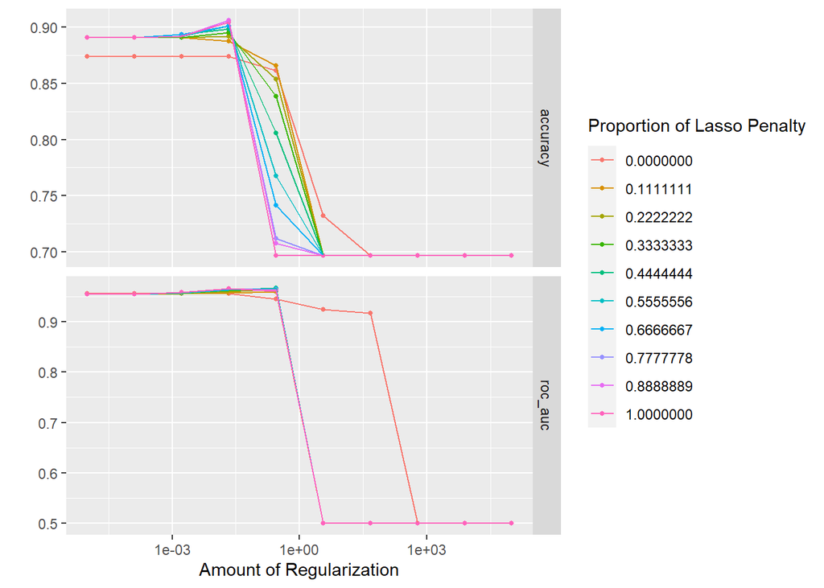

```r
# read file
tune_res_elasticnet2 <- read_rds(file = "C:/Users/cupca/OneDrive/Documents/UCSB/Fall2022/PSTAT131/Final-Project/Final-Project-laurenrhuang/saved_models/tune_res_elasticnet2.rds")

# autoplot
autoplot(tune_res_elasticnet2)
```

```r
# show the best models according to roc_auc
show_best(tune_res_elasticnet2, metric = "roc_auc")
```

```
## # A tibble: 5 × 8
##   penalty mixture .metric .estimator  mean     n std_err .config
##     <dbl>   <dbl> <chr>   <chr>      <dbl> <int>   <dbl> <chr>
## 1  0.278    0.333 roc_auc binary     0.966     5 0.00585 Preprocessor1_Model035
## 2  0.278    0.444 roc_auc binary     0.966     5 0.00586 Preprocessor1_Model045
## 3  0.0215   0.889 roc_auc binary     0.965     5 0.00748 Preprocessor1_Model084
## 4  0.278    0.556 roc_auc binary     0.965     5 0.00606 Preprocessor1_Model055
## 5  0.0215   1     roc_auc binary     0.965     5 0.00798 Preprocessor1_Model094
```

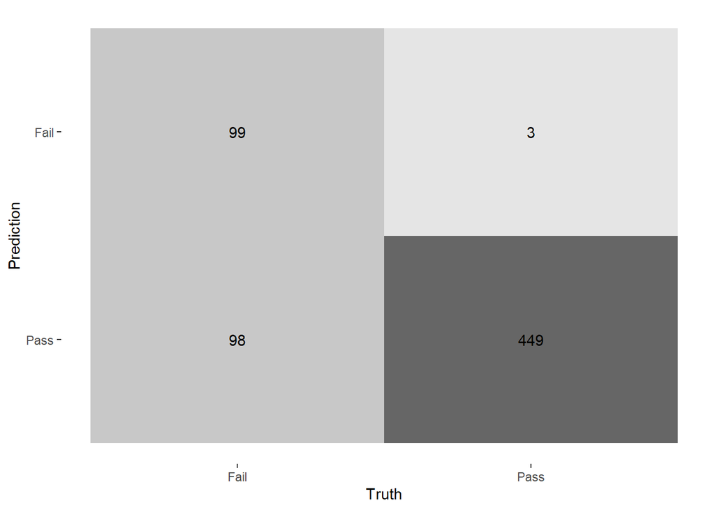

```r
# select the best
en_best_rocauc2 <- select_best(tune_res_elasticnet2, metric = "roc_auc")

# fit model to training set
elasticnet2_final <- finalize_workflow(multinom_reg_wf2, en_best_rocauc2)
elasticnet2_final_fit <- fit(elasticnet2_final, data = grades_train2_fctr_nocourse)

# confusion matrix
augment(elasticnet2_final_fit, new_data = grades_train2_fctr_nocourse) %>%
  conf_mat(truth = g3, estimate = .pred_class) %>%
  autoplot(type = "heatmap")
```

```r
# evaluate accuracy and roc_auc
augment(elasticnet2_final_fit, new_data = grades_train2_fctr_nocourse) %>%
  accuracy(truth = g3, estimate = .pred_class)
```

```
## # A tibble: 1 × 3
##   .metric  .estimator .estimate
##   <chr>    <chr>          <dbl>
## 1 accuracy binary         0.844
```

```r
augment(elasticnet2_final_fit, new_data = grades_train2_fctr_nocourse) %>%
  roc_auc(truth = g3, estimate = .pred_Fail)
```

```
## # A tibble: 1 × 3
##   .metric .estimator .estimate
##   <chr>   <chr>          <dbl>
## 1 roc_auc binary         0.967
```

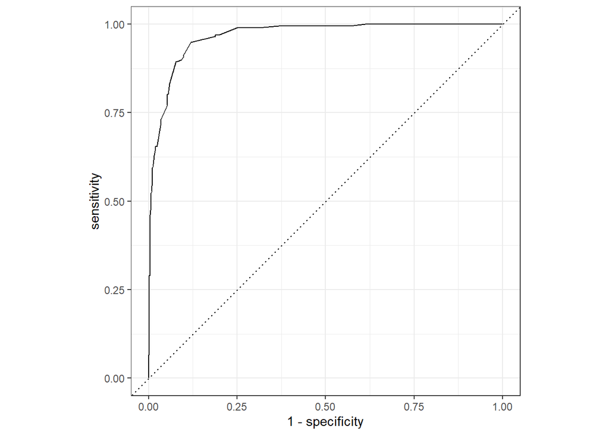

```r
# ROC curve
augment(elasticnet2_final_fit, new_data = grades_train2_fctr_nocourse) %>%
  roc_curve(truth = g3, estimate = .pred_Fail) %>%
  autoplot()
```

While Method 2 also performed well, we got better accuracy and roc_auc using Method 1 on the elastic net model. We can verify the details by observing the confusion matrix and plotting ROC curves for each method. Are there any other models that can give us even better results?

### Decision Tree

Next, we move to the tree model family. A decision tree is one type of tree model, you can think of a decision tree as a branching method that looks at every possible output for a specific input. We can take a look at the visualization of a decision tree.

#### Method 1. merged dataset

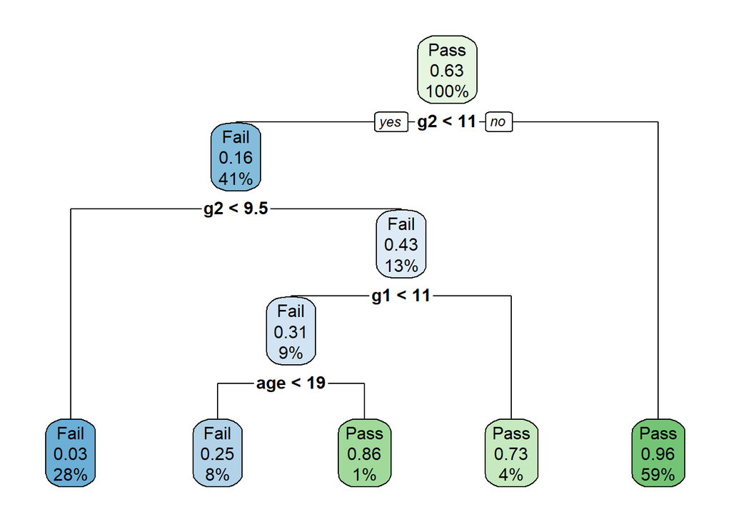

```r
# decision tree engine
tree_spec <- decision_tree() %>%
  set_engine("rpart")
class_tree_spec <- tree_spec %>%
  set_mode("classification")

# fit model
class_tree_fit <- class_tree_spec %>%
  fit(g3 ~ ., data = grades_train_fctr)

# visualize
class_tree_fit %>%
  extract_fit_engine() %>%
  rpart.plot()
```

Like the previous models, we set an engine and make a grid to tune the appropriate parameters. The cost complexity parameter is very important because it helps “prune” the tree. This means it reduces the size of the tree and keeps the tree from having “too many branches” or “leaf nodes.” A tree that has too many branches or leaf nodes could lead to model overfitting. Let’s set up the engine and workflow for a decision tree. Here, we tune the cost complexity parameter and see which value gives us the best results.

```r
# decision tree engine
tree_spec <- decision_tree() %>%
  set_engine("rpart") %>%
  set_mode("classification")

# create workflow
class_tree_wf <- workflow() %>%
  add_model(tree_spec %>% set_args(cost_complexity = tune())) %>%
  add_recipe(grades_recipe1_fctr)

# create grid
set.seed(3435)
param_grid <- grid_regular(cost_complexity(range = c(-3, -1)), levels = 10)
```

This time our grid holds the values of the cost complexity parameter. Below, we tune the model to see which cost complexity parameter gives us the best accuracy and roc_auc. Note: we use the same number of folds we made earlier with the elastic net model!

```r
# fit with tune_grid
classtree_tune_res <- tune_grid(
  class_tree_wf,
  resamples = grades_folds_fctr_new,
  grid = param_grid,
  metrics = metric_set(accuracy, roc_auc)
)

# write file
write_rds(classtree_tune_res, file = "C:/Users/cupca/OneDrive/Documents/UCSB/Fall2022/PSTAT131/Final-Project/Final-Project-laurenrhuang/saved_models/classtree_tune_res.rds")
```

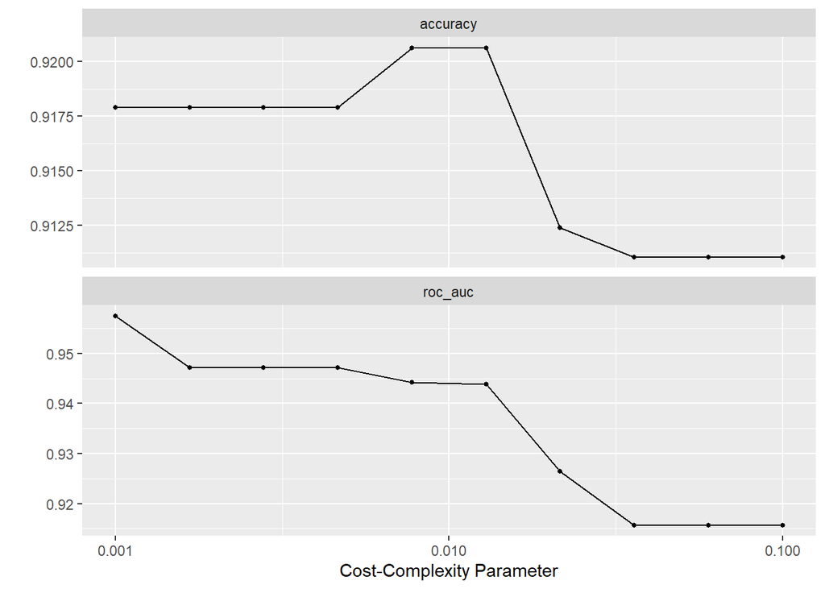

```r
# read file
classtree_tune_res <- read_rds(file = "C:/Users/cupca/OneDrive/Documents/UCSB/Fall2022/PSTAT131/Final-Project/Final-Project-laurenrhuang/saved_models/classtree_tune_res.rds")

# cost-complexity autoplot
autoplot(classtree_tune_res)
```

We can take a closer look at all the tuned values of cost-complexity, and choose the one that gives us the best results. This matches what we see in the plot above, which is good.

```r
# show the best models according to roc_auc
show_best(classtree_tune_res, metric = "roc_auc")
```

```
## # A tibble: 5 × 7
##   cost_complexity .metric .estimator  mean     n std_err .config
##             <dbl> <chr>   <chr>      <dbl> <int>   <dbl> <chr>
## 1         0.001   roc_auc binary     0.957     5 0.00610 Preprocessor1_Model01
## 2         0.00167 roc_auc binary     0.947     5 0.00866 Preprocessor1_Model02
## 3         0.00278 roc_auc binary     0.947     5 0.00866 Preprocessor1_Model03
## 4         0.00464 roc_auc binary     0.947     5 0.00866 Preprocessor1_Model04
## 5         0.00774 roc_auc binary     0.944     5 0.00817 Preprocessor1_Model05
```

```r
# select the best
classtree_best_complexity <- select_best(classtree_tune_res, metric = "roc_auc")

# fit
classtree_final1 <- finalize_workflow(class_tree_wf, classtree_best_complexity)
classtree_final1_fit <- fit(classtree_final1, data = grades_train_fctr)

# evaluate accuracy and roc_auc
augment(classtree_final1_fit, new_data = grades_train_fctr) %>%
  accuracy(truth = g3, estimate = .pred_class)
```

```
## # A tibble: 1 × 3
##   .metric  .estimator .estimate
##   <chr>    <chr>          <dbl>
## 1 accuracy binary         0.941
```

```r
augment(classtree_final1_fit, new_data = grades_train_fctr) %>%
  roc_auc(truth = g3, estimate = .pred_Fail)
```

```
## # A tibble: 1 × 3
##   .metric .estimator .estimate
##   <chr>   <chr>          <dbl>
## 1 roc_auc binary         0.977
```

#### Method 2. Portuguese for training, Maths for testing

Repeat the same steps for Method 2:

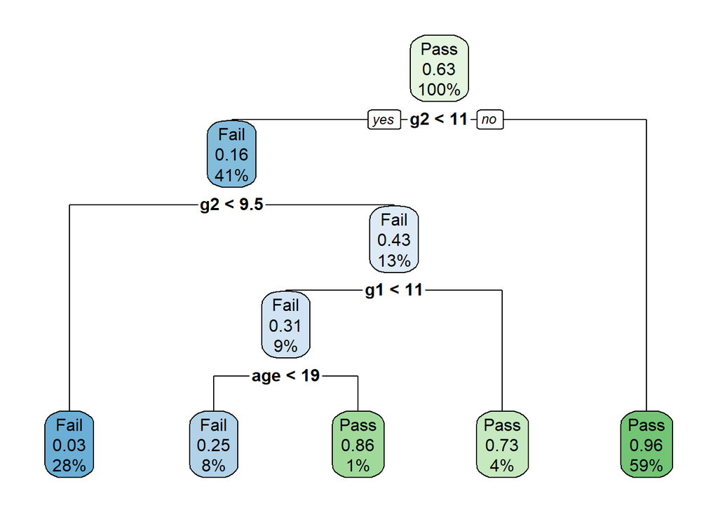

```r
# decision tree engine
tree_spec <- decision_tree() %>%
  set_engine("rpart")
class_tree_spec <- tree_spec %>%
  set_mode("classification")

# fit model
class_tree_fit2 <- class_tree_spec %>%
  fit(g3 ~ ., data = grades_train2_fctr)

# visualize
class_tree_fit %>%
  extract_fit_engine() %>%
  rpart.plot()
```

```r
# decision tree engine
tree_spec <- decision_tree() %>%
  set_engine("rpart") %>%
  set_mode("classification")

# create workflow
class_tree_wf2 <- workflow() %>%
  add_model(tree_spec %>% set_args(cost_complexity = tune())) %>%
  add_recipe(grades_recipe2_fctr)
```

```r
# fit with tune_grid
classtree_tune_res2 <- tune_grid(
  class_tree_wf2,
  resamples = grades_folds2_fctr_new,
  grid = param_grid,
  metrics = metric_set(accuracy, roc_auc)
)

# write file
write_rds(classtree_tune_res2, file = "C:/Users/cupca/OneDrive/Documents/UCSB/Fall2022/PSTAT131/Final-Project/Final-Project-laurenrhuang/saved_models/classtree_tune_res2.rds")
```

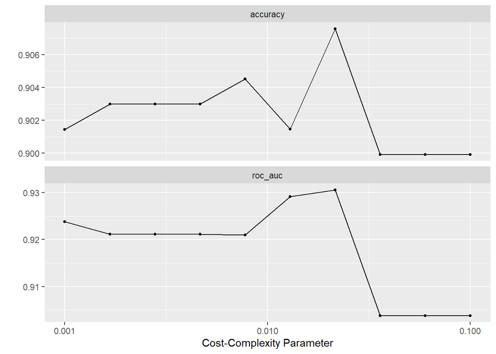

```r
# read file
classtree_tune_res2 <- read_rds(file = "C:/Users/cupca/OneDrive/Documents/UCSB/Fall2022/PSTAT131/Final-Project/Final-Project-laurenrhuang/saved_models/classtree_tune_res2.rds")

# cost-complexity autoplot
autoplot(classtree_tune_res2)
```

```r
# show the best models according to roc_auc
show_best(classtree_tune_res2, metric = "roc_auc")
```

```
## # A tibble: 5 × 7
##   cost_complexity .metric .estimator  mean     n std_err .config
##             <dbl> <chr>   <chr>      <dbl> <int>   <dbl> <chr>
## 1         0.0215  roc_auc binary     0.931     5 0.00851 Preprocessor1_Model07
## 2         0.0129  roc_auc binary     0.929     5 0.00913 Preprocessor1_Model06
## 3         0.001   roc_auc binary     0.924     5 0.00731 Preprocessor1_Model01
## 4         0.00167 roc_auc binary     0.921     5 0.00892 Preprocessor1_Model02
## 5         0.00278 roc_auc binary     0.921     5 0.00892 Preprocessor1_Model03
```

```r
# select the best
classtree_best_complexity2 <- select_best(classtree_tune_res2, , metric = "roc_auc")

# fit
classtree_final2 <- finalize_workflow(class_tree_wf2, classtree_best_complexity2)
classtree_final_fit2 <- fit(classtree_final2, data = grades_train2_fctr_nocourse)

# evaluate accuracy and roc_auc
augment(classtree_final_fit2, new_data = grades_train2_fctr_nocourse) %>%
  accuracy(truth = g3, estimate = .pred_class)
```

```
## # A tibble: 1 × 3
##   .metric  .estimator .estimate
##   <chr>    <chr>          <dbl>
## 1 accuracy binary         0.915
```

```r
augment(classtree_final_fit2, new_data = grades_train2_fctr_nocourse) %>%
  roc_auc(truth = g3, estimate = .pred_Fail)
```

```
## # A tibble: 1 × 3
##   .metric .estimator .estimate
##   <chr>   <chr>          <dbl>
## 1 roc_auc binary         0.932
```

Between the decision tree models, Method 1 gave us significantly better results than Method 2. Method 1 accuracy was 0.9410959 and roc_auc was 0.9768124. In contrast, Method 2 accuracy was 0.9152542 and roc_auc was 0.9316911. Will fitting multiple trees give us better results than a single decision tree? One example is a boosted tree model.

### Boosted Tree

A boosted tree is like a decision tree, but boosting means that each tree is dependent on prior trees. Boosting uses a group of decision tree models, and learns by fitting the residual of the trees before it. A random forest model is also constructed using multiple decision trees. The difference between the two is that each tree in random forests are independent, whereas the trees in boosted tree models are dependent. But because random forests and boosted tree models involve multiple decision trees, they take a long time to run. For the sake of time, we’ll just try out one of the two options.

#### Method 1. merged dataset

We specify the engine “xgboost” and mode “classification” with boost_tree(). As you might have noticed, several classification models we’ve fitted have made us specify a mode. It is extremely important to specify because some engines work with both regression and classification. A boosted tree is one of these. We make our workflow, and specify to tune the number of trees. Then we create a grid to hold the values for tuning. Tuning will help us find the optimal number of trees.

```r
# set boosted tree engine
xgb_spec <- boost_tree() %>%
  set_engine("xgboost") %>%
  set_mode("classification")

# create workflow
xgb_wf <- workflow() %>%
  add_model(xgb_spec %>% set_args(trees = tune())) %>%
  add_recipe(grades_recipe1_fctr)

# create grid
param_grid2 <- grid_regular(trees(range = c(10, 2000)),
                            levels = 10)
```

The tune_grid() process is the same as before, we use the folds created above in the elastic net model, and the grid we made.

```r
# fit using tune_grid
boostedtree_tune_res <- tune_grid(
  xgb_wf,
  resamples = grades_folds_fctr_new,
  grid = param_grid2,
  metrics = metric_set(accuracy, roc_auc)
)

# write file
write_rds(boostedtree_tune_res, file = "C:/Users/cupca/OneDrive/Documents/UCSB/Fall2022/PSTAT131/Final-Project/Final-Project-laurenrhuang/saved_models/boostedtree_tune_res.rds")
```

Making some plots shows us that both accuracy and roc_auc are highest when the number of trees is small, around 10.

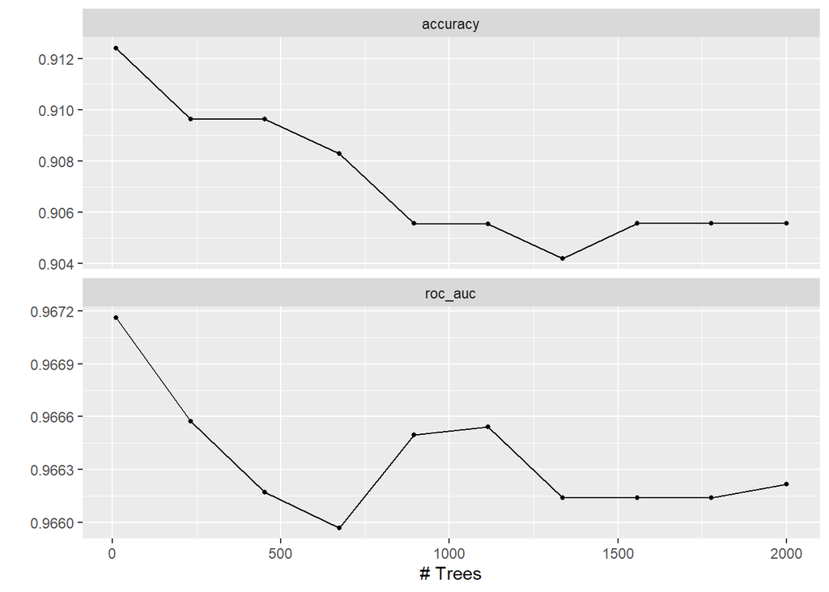

```r
boostedtree_tune_res <- read_rds(file = "C:/Users/cupca/OneDrive/Documents/UCSB/Fall2022/PSTAT131/Final-Project/Final-Project-laurenrhuang/saved_models/boostedtree_tune_res.rds")

# autoplot
autoplot(boostedtree_tune_res)
```

```r
# show the best models according to roc_auc
show_best(boostedtree_tune_res, metric = "roc_auc")
```

```
## # A tibble: 5 × 7
##   trees .metric .estimator  mean     n std_err .config
##   <int> <chr>   <chr>      <dbl> <int>   <dbl> <chr>
## 1    10 roc_auc binary     0.967     5 0.00491 Preprocessor1_Model01
## 2   231 roc_auc binary     0.967     5 0.00732 Preprocessor1_Model02
## 3  1115 roc_auc binary     0.967     5 0.00783 Preprocessor1_Model06
## 4   894 roc_auc binary     0.966     5 0.00777 Preprocessor1_Model05
## 5  2000 roc_auc binary     0.966     5 0.00775 Preprocessor1_Model10
```

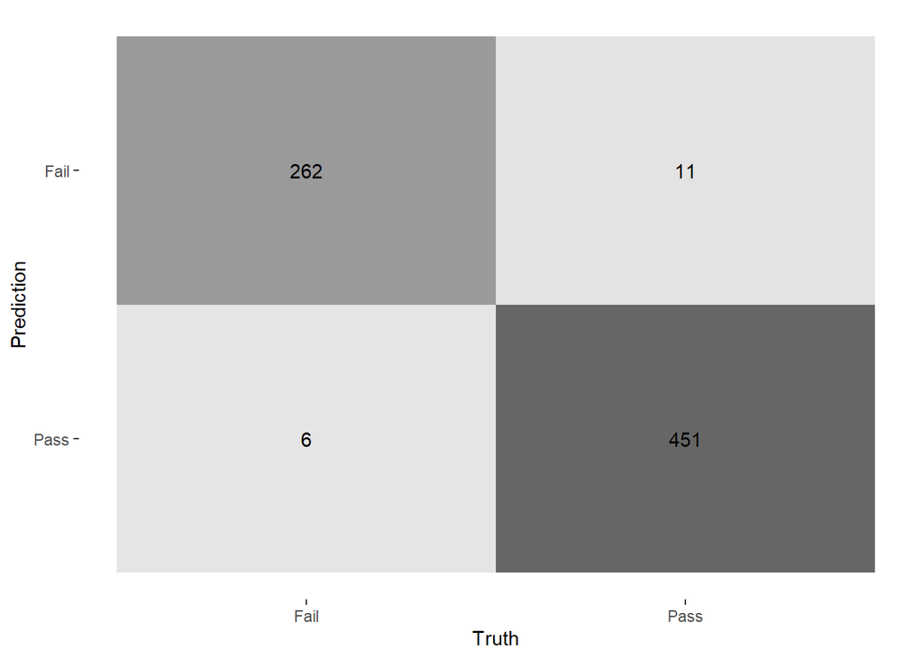

```r
# select the best
boostedtree_best_complexity <- select_best(boostedtree_tune_res, metric = "roc_auc")

# fit
xgb_final1 <- finalize_workflow(xgb_wf, boostedtree_best_complexity)
xgb_final_fit1 <- fit(xgb_final1, data = grades_train_fctr)

# confusion matrix
augment(xgb_final_fit1, new_data = grades_train_fctr) %>%
  conf_mat(truth = g3, estimate = .pred_class) %>%
  autoplot(type = "heatmap")
```

```r
# evaluate accuracy and roc_auc
augment(xgb_final_fit1, new_data = grades_train_fctr) %>%
  accuracy(truth = g3, estimate = .pred_class)
```

```
## # A tibble: 1 × 3
##   .metric  .estimator .estimate
##   <chr>    <chr>          <dbl>
## 1 accuracy binary         0.977
```

```r
augment(xgb_final_fit1, new_data = grades_train_fctr) %>%
  roc_auc(truth = g3, estimate = .pred_Fail)
```

```
## # A tibble: 1 × 3
##   .metric .estimator .estimate
##   <chr>   <chr>          <dbl>
## 1 roc_auc binary         0.998
```

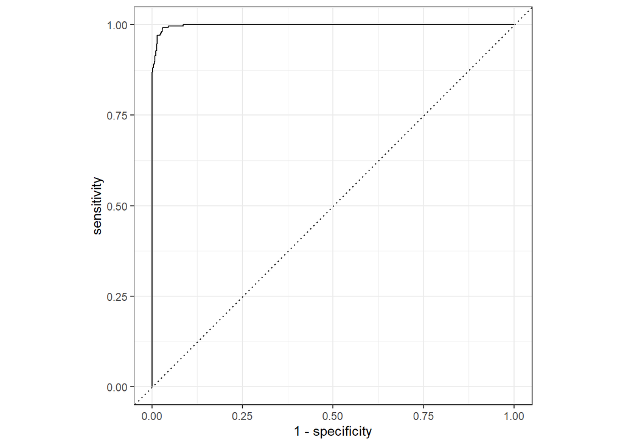

```r
# roc curve
augment(xgb_final_fit1, new_data = grades_train_fctr) %>%
  roc_curve(truth = g3, estimate = .pred_Fail) %>%
  autoplot()
```

Method 1 gives us an accuracy of 0.9767123, and roc_auc of 0.9979243. That’s close to perfect! The results match our ROC curve as well. Will Method 2 do any better?

#### Method 2. Portuguese for training, Maths for testing

Repeat the same steps for Method 2:

```r
# set boosted tree engine
xgb_spec <- boost_tree() %>%
  set_engine("xgboost") %>%
  set_mode("classification")

# create workflow
xgb_wf2 <- workflow() %>%
  add_model(xgb_spec %>% set_args(trees = tune())) %>%
  add_recipe(grades_recipe2_fctr)

# create grid
param_grid2 <- grid_regular(trees(range = c(10, 2000)),
                            levels = 10)
```

```r
# fit using tune_grid
boostedtree_tune_res2 <- tune_grid(
  xgb_wf2,
  resamples = grades_folds2_fctr_new,
  grid = param_grid2,
  metrics = metric_set(accuracy, roc_auc)
)

# write file
write_rds(boostedtree_tune_res2, file = "C:/Users/cupca/OneDrive/Documents/UCSB/Fall2022/PSTAT131/Final-Project/Final-Project-laurenrhuang/saved_models/boostedtree_tune_res2.rds")
```

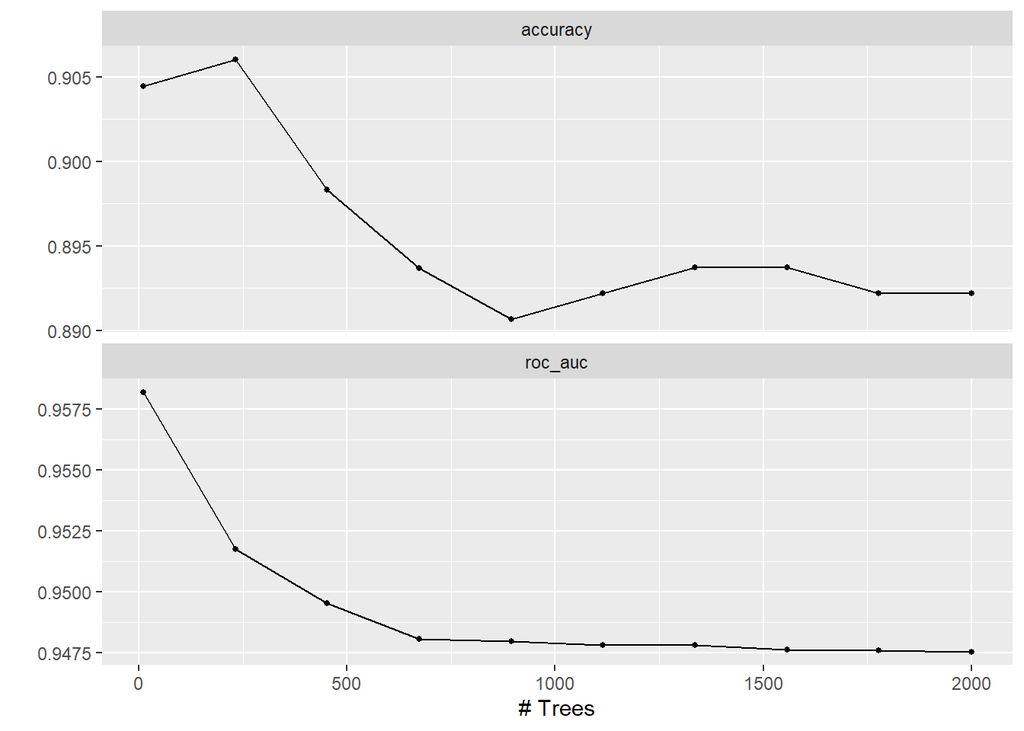

```r
boostedtree_tune_res2 <- read_rds(file = "C:/Users/cupca/OneDrive/Documents/UCSB/Fall2022/PSTAT131/Final-Project/Final-Project-laurenrhuang/saved_models/boostedtree_tune_res2.rds")

# autoplot
autoplot(boostedtree_tune_res2)
```

```r
# show the best models according to roc_auc
show_best(boostedtree_tune_res2, metric = "roc_auc")
```

```
## # A tibble: 5 × 7
##   trees .metric .estimator  mean     n std_err .config
##   <int> <chr>   <chr>      <dbl> <int>   <dbl> <chr>
## 1    10 roc_auc binary     0.958     5 0.00624 Preprocessor1_Model01
## 2   231 roc_auc binary     0.952     5 0.00511 Preprocessor1_Model02
## 3   452 roc_auc binary     0.950     5 0.00553 Preprocessor1_Model03
## 4   673 roc_auc binary     0.948     5 0.00583 Preprocessor1_Model04
## 5   894 roc_auc binary     0.948     5 0.00595 Preprocessor1_Model05
```

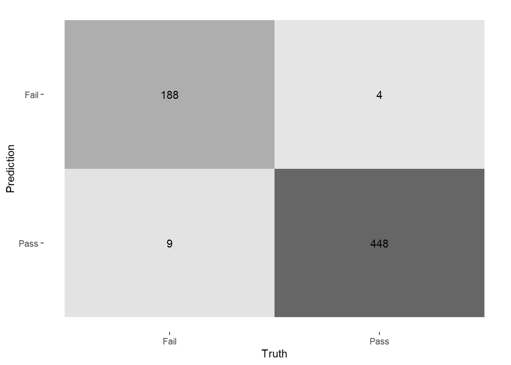

```r
# select the best
boostedtree_best_complexity2 <- select_best(boostedtree_tune_res2, metric = "roc_auc")

# fit
xgb_final2 <- finalize_workflow(xgb_wf2, boostedtree_best_complexity2)
xgb_final_fit2 <- fit(xgb_final2, data = grades_train2_fctr_nocourse)

# confusion matrix
augment(xgb_final_fit2, new_data = grades_train2_fctr_nocourse) %>%
  conf_mat(truth = g3, estimate = .pred_class) %>%
  autoplot(type = "heatmap")
```

```r
# evaluate accuracy and roc_auc
augment(xgb_final_fit2, new_data = grades_train2_fctr_nocourse) %>%
  accuracy(truth = g3, estimate = .pred_class)
```

```
## # A tibble: 1 × 3
##   .metric  .estimator .estimate
##   <chr>    <chr>          <dbl>
## 1 accuracy binary         0.980
```

```r
augment(xgb_final_fit2, new_data = grades_train2_fctr_nocourse) %>%
  roc_auc(truth = g3, estimate = .pred_Fail)
```

```
## # A tibble: 1 × 3
##   .metric .estimator .estimate
##   <chr>   <chr>          <dbl>
## 1 roc_auc binary         0.997
```

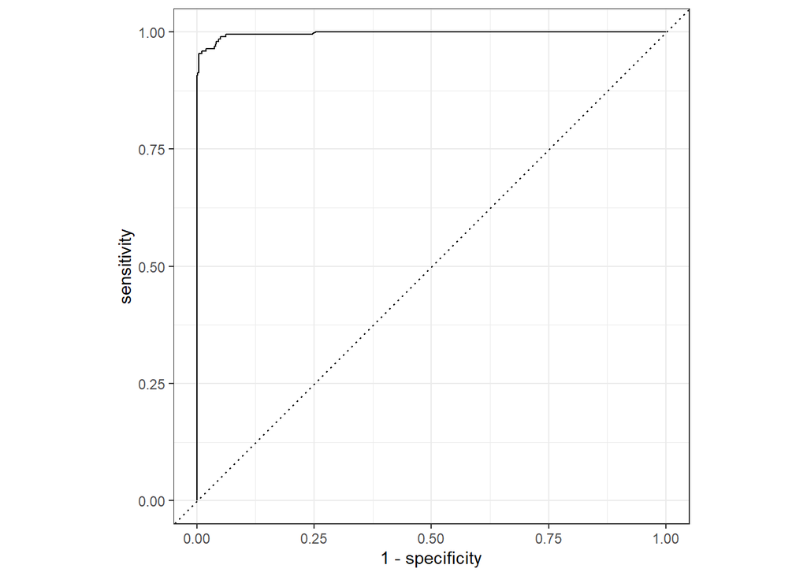

```r
# roc curve
augment(xgb_final_fit2, new_data = grades_train2_fctr_nocourse) %>%
  roc_curve(truth = g3, estimate = .pred_Fail) %>%
  autoplot()
```

Method 2 also does very well, the accuracy of 0.9799692 is higher than Method 1 but the roc_auc of 0.996979 is lower than Method 1. Both boosted tree models have given us the highest accuracy and roc_auc values out of all the models fitted so far.

## Conclusion

After testing both regression and classification methods, we have determined that most of our classification models performed better than the regression models. But between all of the classification models we fitted, which was the best? Let’s compare the roc_auc values of all the models.

```r
# Logistic Regression
grades_log_reg_auc <- augment(log_fit, new_data = grades_train_fctr) %>%
  roc_auc(truth = g3, estimate = .pred_Fail) %>%
  select(.estimate)

grades_log_reg_auc2 <- augment(log_fit2, new_data = grades_train2_fctr) %>%
  roc_auc(truth = g3, estimate = .pred_Fail) %>%
  select(.estimate)

# LDA
grades_lda_auc <- augment(lda_fit, new_data = grades_train_fctr) %>%
  roc_auc(truth = g3, estimate = .pred_Fail) %>%
  select(.estimate)

grades_lda_auc2 <- augment(lda_fit2, new_data = grades_train2_fctr) %>%
  roc_auc(truth = g3, estimate = .pred_Fail) %>%
  select(.estimate)

# QDA
grades_qda_auc <- augment(qda_fit, new_data = grades_train_fctr) %>%
  roc_auc(truth = g3, estimate = .pred_Fail) %>%
  select(.estimate)

grades_qda_auc2 <- augment(qda_fit2, new_data = grades_train2_fctr) %>%
  roc_auc(truth = g3, estimate = .pred_Fail) %>%
  select(.estimate)

# Log K-Fold CV
grades_log_kfold_auc <- augment(fit_log_kfold) %>%
  roc_auc(truth = g3, estimate = .pred_Fail) %>%
  select(.estimate)

grades_log_kfold_auc2 <- augment(fit_log2_kfold) %>%
  roc_auc(truth = g3, estimate = .pred_Fail) %>%
  select(.estimate)

# Elastic Net
grades_elasticnet_auc <- augment(elasticnet1_final_fit, new_data = grades_train_fctr) %>%
  roc_auc(truth = g3, estimate = .pred_Fail) %>%
  select(.estimate)

grades_elasticnet_auc2 <- augment(elasticnet2_final_fit, new_data = grades_train2_fctr_nocourse) %>%
  roc_auc(truth = g3, estimate = .pred_Fail) %>%
  select(.estimate)

# Decision Tree
grades_dt_auc <- augment(classtree_final1_fit, new_data = grades_train_fctr) %>%
  roc_auc(truth = g3, estimate = .pred_Fail) %>%
  select(.estimate)

grades_dt_auc2 <- augment(classtree_final_fit2, new_data = grades_train2_fctr_nocourse) %>%
  roc_auc(truth = g3, estimate = .pred_Fail) %>%
  select(.estimate)

# Boosted Tree
grades_xgb_auc <- augment(xgb_final_fit1, new_data = grades_train_fctr) %>%
  roc_auc(truth = g3, estimate = .pred_Fail) %>%
  select(.estimate)

grades_xgb_auc2 <- augment(xgb_final_fit2, new_data = grades_train2_fctr_nocourse) %>%
  roc_auc(truth = g3, estimate = .pred_Fail) %>%
  select(.estimate)

grades_roc_aucs <- c(grades_log_reg_auc$.estimate,
                           grades_log_reg_auc2$.estimate,
                           grades_lda_auc$.estimate,
                           grades_lda_auc2$.estimate,
                           grades_qda_auc$.estimate,
                           grades_qda_auc2$.estimate,
                           grades_log_kfold_auc$.estimate,
                           grades_log_kfold_auc2$.estimate,
                           grades_elasticnet_auc$.estimate,
                           grades_elasticnet_auc2$.estimate,
                           grades_dt_auc$.estimate,
                           grades_dt_auc2$.estimate,
                           grades_xgb_auc$.estimate,
                           grades_xgb_auc2$.estimate)

grades_mod_names <- c("Log Regression Method 1",
                      "Log Regression Method 2",
                      "LDA Method 1",
                      "LDA Method 2",
                      "QDA Method 1",
                      "QDA Method 2",
                      "Log Regression K-Fold CV Method 1",
                      "Log Regression K-Fold CV Method 2",
                      "Elastic Net Method 1",
                      "Elastic Net Method 2",
                      "Decision Tree Method 1",
                      "Decision Tree Method 2",
                      "Boosted Tree Method 1",
                      "Boosted Tree Method 2")
```

```r
grades_results <- tibble(Model = grades_mod_names,
                             ROC_AUC = grades_roc_aucs)

grades_results <- grades_results %>%
  arrange(-grades_roc_aucs)

grades_results
```

```
## # A tibble: 14 × 2
##    Model                             ROC_AUC
##    <chr>                               <dbl>
##  1 Boosted Tree Method 1               0.998
##  2 Boosted Tree Method 2               0.997
##  3 Log Regression Method 1             0.985
##  4 Elastic Net Method 1                0.978
##  5 Log Regression Method 2             0.977
##  6 Decision Tree Method 1              0.977
##  7 LDA Method 1                        0.975
##  8 Log Regression K-Fold CV Method 1   0.969
##  9 QDA Method 1                        0.967
## 10 Elastic Net Method 2                0.967
## 11 LDA Method 2                        0.965
## 12 QDA Method 2                        0.964
## 13 Log Regression K-Fold CV Method 2   0.951
## 14 Decision Tree Method 2              0.932
```

These here are the roc_auc values of our classification models. A dot plot will help visualize the results.

```r
grades_dot_plot <- ggplot(grades_results, aes(x = Model, y = ROC_AUC)) +
  geom_point(fill = "blue", col = "blue", size=5) +
  geom_segment(aes(x = Model,
                   xend = Model,
                   y=min(ROC_AUC),
                   yend = max(ROC_AUC)),
               linetype = "dashed",
               linewidth=0.5) +
  labs(title = "Model Performance") +
  theme_minimal() +
  coord_flip()
```

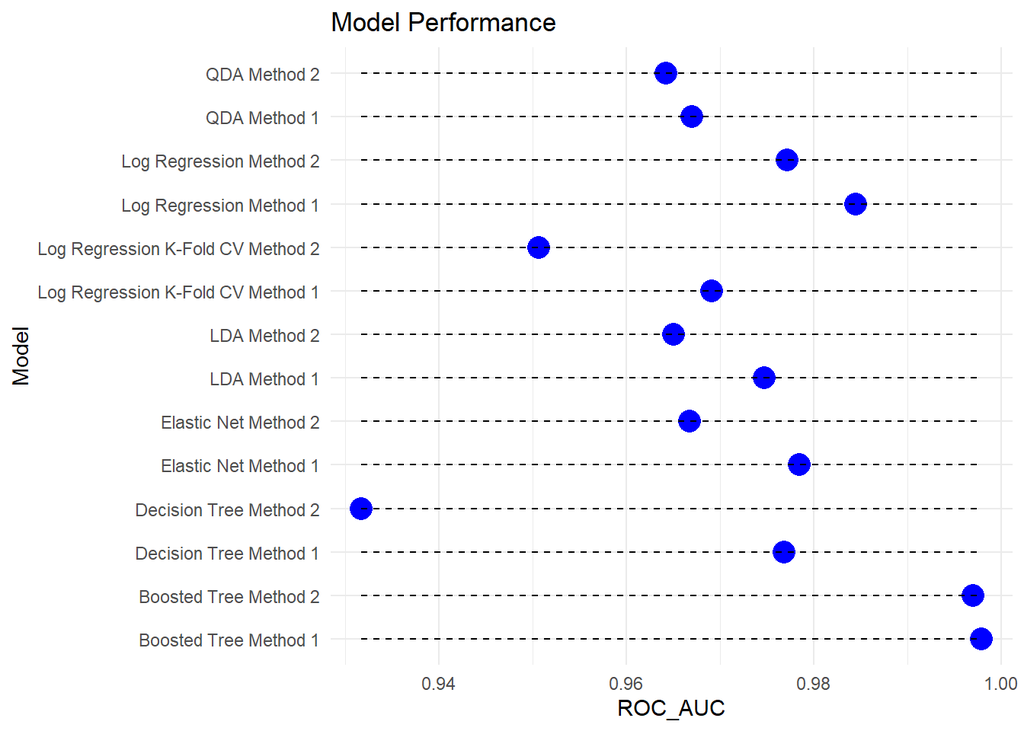

```r
grades_dot_plot
```

```r
# show metrics
show_best(boostedtree_tune_res, metric = "roc_auc")
```

```
## # A tibble: 5 × 7
##   trees .metric .estimator  mean     n std_err .config
##   <int> <chr>   <chr>      <dbl> <int>   <dbl> <chr>
## 1    10 roc_auc binary     0.967     5 0.00491 Preprocessor1_Model01
## 2   231 roc_auc binary     0.967     5 0.00732 Preprocessor1_Model02
## 3  1115 roc_auc binary     0.967     5 0.00783 Preprocessor1_Model06
## 4   894 roc_auc binary     0.966     5 0.00777 Preprocessor1_Model05
## 5  2000 roc_auc binary     0.966     5 0.00775 Preprocessor1_Model10
```